# Variation in vocal behavior under varying stress levels

Budgie INBRE stress and contact calls

[Marcelo Araya-Salas, PhD](http://marceloarayasalas.weebly.com/) & [Timothy Wright, PhD](https://wrightbehaviorlab.org/)

2025-06-25

Source code and data found at https://github.com/maRce10/budgie_inbre_stress_vocal_output

## Load packages

```r
## add 'developer' to packages to be installed from github
x <- c("remotes", "lubridate", "readxl", "pbapply", "viridis", "ggplot2",
    "kableExtra", "knitr", "formatR", "MASS", "sp", "GGally", "brms",
    "lme4", "dplyr", "purrr", "forcats", "tidyr", "modelr", "tidybayes",
    "cowplot", "ggrepel", "posterior", "ggridges", "maRce10/PhenotypeSpace",
    "corrplot", "DT")

source("~/Dropbox/R_package_testing/sketchy/R/load_packages.R")
load_packages(x)

source("~/Dropbox/R_package_testing/brmsish/R/extended_summary.R")
source("~/Dropbox/R_package_testing/brmsish/R/helpers.R")
source("~/Dropbox/R_package_testing/brmsish/R/read_summary.R")
source("~/Dropbox/R_package_testing/brmsish/R/check_rds_fits.R")

print_kable <- function(x) {
    kb <- kable(x, row.names = TRUE, digits = 4, "html")
    kb <- kable_styling(kb, bootstrap_options = c("striped", "hover",
        "condensed", "responsive"))
    scroll_box(kb, width = "100%")
}

data_table <- function(x, digits = 3) {
    if (is.matrix(x))
        x <- as.data.frame(x)
    datatable(x) |>
        formatRound(columns = which(sapply(x, is.numeric)), digits = digits)
}
```

## Functions and global parameters

```r
opts_knit$set(root.dir = "..")

# set evaluation false
opts_chunk$set(fig.width = 10, fig.height = 6, warning = FALSE, message = FALSE,
    tidy = TRUE)

read_excel_df <- function(...) data.frame(read_excel(...))


# for reading months in english format
sl <- Sys.setlocale(locale = "en_US.UTF-8")


standard_error <- function(x) sd(x)/sqrt(length(x))

cols <- viridis(10, alpha = 0.7)

col_pointrange <- cols[7]
```

```r
# read ext sel tab calls
sels <- read.csv("./data/processed/tailored_budgie_calls_sel_tab.csv")

# keep only spectrographic parameters
sels <- sels[, c("sound.files", "selec", "duration", "meanfreq", "sd",
    "freq.median", "freq.IQR", "time.IQR", "skew", "kurt", "sp.ent",
    "time.ent", "entropy", "meandom", "mindom", "maxdom", "dfrange",
    "modindx", "meanpeakf")]

sels$ID <- sapply(sels$sound.files, function(x) strsplit(x, "_")[[1]][1])
sels$month <- sapply(sels$sound.files, function(x) strsplit(x, "_")[[1]][2])
sels$day <- sapply(sels$sound.files, function(x) strsplit(x, "_")[[1]][3])
sels$year <- sapply(sels$sound.files, function(x) strsplit(x, "_")[[1]][4])

sels$date <- paste(sels$day, substr(sels$month, 0, 3), sels$year,
    sep = "-")

sels$date <- as.Date(sels$date, format = "%d-%b-%Y")

# acoustic measurements
areas_by_week <- readRDS("./data/processed/acoustic_space_area_by_individual_and_week.RDS")

indiv_ovlp <- readRDS("./data/processed/acoustic_space_density_overlap_to_first_week_by_individual.RDS")

indiv_ovlp$treatment <- factor(indiv_ovlp$treatment, levels = c("Control",
    "Medium Stress", "High Stress"))

group_ovlp <- readRDS("./data/processed/acoustic_space_density_overlap_to_group_by_week.RDS")

# group_ovlp <- do.call(rbind, lapply(unique(group_ovlp$ID),
# function(x) { X <- group_ovlp[group_ovlp$ID == x, ]
# X$overlap.to.group <- X$overlap.to.group -
# X$overlap.to.group[X$week ==
# min(as.numeric(as.character(X$week)))] X$distance.to.group <-
# X$distance.to.group - X$distance.to.group[X$week ==
# min(as.numeric(as.character(X$week)))] return(X) }))

group_ovlp$treatment <- factor(group_ovlp$treatment, levels = c("Control",
    "Medium Stress", "High Stress"))
```

## Counts per individual

```r
df <- as.data.frame(table(sels$ID))

names(df) <- c("ID", "Sample_size")

df <- df[order(df$Sample_size, decreasing = FALSE), ]

kb <- kable(df, row.names = FALSE)

kb <- kable_styling(kb, bootstrap_options = c("striped", "hover",
    "condensed", "responsive"), position = "float_left")

print(kb)
```

| ID | Sample_size |
| --- | --- |
| 132YGMM | 6 |
| 125YGMM | 12 |
| 160YGHM | 16 |
| 310YGHM | 21 |
| 393YGHM | 25 |
| 303YGHM | 37 |
| 398WBHM | 41 |
| 365YGHM | 44 |
| 399YGLM | 46 |
| 300YGHM | 47 |
| 270YGHM | 64 |
| 407YGHM | 97 |
| 386WBHM | 100 |
| 377WWLM | 108 |
| 367WWNM | 119 |
| 371YYLM | 149 |
| 397YGHM | 175 |
| 378YYLM | 195 |
| 404WBHM | 196 |
| 258YGHM | 223 |
| 389WWLM | 230 |
| 262YGHM | 306 |
| 400YGHM | 360 |
| 388YGLM | 377 |
| 327YYLM | 404 |
| 396YBHM | 455 |
| 403WBHM | 566 |
| 356WBHM | 761 |
| 361YGHM | 767 |
| 402YGHM | 849 |
| 395WBHM | 854 |
| 360YGHM | 900 |
| 390WBHM | 935 |
| 405YBHM | 975 |
| 385YBHM | 1256 |
| 394YBHM | 1693 |

# Add metadata

```r
metadat <- read_excel_df("./data/raw/INBREStress_MasterDataSheet_14Nov19.xlsx")

# head(metadat)

sels$ID[sels$ID == "125YGMM"] <- "125YGHM"
sels$ID[sels$ID == "394YBHM"] <- "394WBHM"

# setdiff(sels$ID, metadat$Bird.ID) setdiff(metadat$Bird.ID,
# sels$ID)

sels$treatment <- sapply(1:nrow(sels), function(x) {

    metadat$Treatment[metadat$Bird.ID == sels$ID[x]][1]

})


sels$treatment.room <- sapply(1:nrow(sels), function(x) {

    metadat$Treatment.Room[metadat$Bird.ID == sels$ID[x]][1]

})


sels$round <- sapply(1:nrow(sels), function(x) {

    metadat$Round[metadat$Bird.ID == sels$ID[x]][1]

})

sels$source.room <- sapply(1:nrow(sels), function(x) {

    metadat$Source.Room[metadat$Bird.ID == sels$ID[x]][1]

})

sels$record.group <- sapply(1:nrow(sels), function(x) {

    metadat$Record.Group[metadat$Bird.ID == sels$ID[x]][1]

})


# add week
out <- lapply(unique(sels$round), function(x) {

    Y <- sels[sels$round == x, ]

    min_date <- min(Y$date)
    week_limits <- min_date + seq(0, 100, by = 7)

    Y$week <- NA
    for (i in 2:length(week_limits)) Y$week[Y$date >= week_limits[i -
        1] & Y$date < week_limits[i]] <- i - 1

    return(Y)
})

sels <- do.call(rbind, out)


sels$cort.baseline <- sapply(1:nrow(sels), function(x) {

    if (sels$week[x] == 1)
        out <- metadat$D3.CORT.Baseline[metadat$Bird.ID == sels$ID[x]][1]

    if (sels$week[x] == 2)
        out <- metadat$D7.CORT.Baseline[metadat$Bird.ID == sels$ID[x]][1]

    if (sels$week[x] == 3)
        out <- metadat$D14.CORT.Baseline[metadat$Bird.ID == sels$ID[x]][1]

    if (sels$week[x] == 4)
        out <- metadat$D21.CORT.Baseline[metadat$Bird.ID == sels$ID[x]][1]

    if (sels$week[x] == 5)
        out <- metadat$D28.CORT.Baseline[metadat$Bird.ID == sels$ID[x]][1]

    return(out)
})


sels$cort.stress <- sapply(1:nrow(sels), function(x) {

    if (sels$week[x] == 1)
        out <- metadat$D3.CORT.Stress[metadat$Bird.ID == sels$ID[x]][1]

    if (sels$week[x] == 2)
        out <- metadat$D7.CORT.Stress[metadat$Bird.ID == sels$ID[x]][1]

    if (sels$week[x] == 3)
        out <- metadat$D14.CORT.Stress[metadat$Bird.ID == sels$ID[x]][1]

    if (sels$week[x] == 4)
        out <- metadat$D21.CORT.Stress[metadat$Bird.ID == sels$ID[x]][1]

    if (sels$week[x] == 5)
        out <- metadat$D28.CORT.Stress[metadat$Bird.ID == sels$ID[x]][1]

    return(out)
})

sels$stress.response <- sels$cort.stress  #- sels$cort.baseline

sels$weight <- sapply(1:nrow(sels), function(x) {

    if (sels$week[x] == 1)
        out <- metadat$D3.Bird.Weight..g.[metadat$Bird.ID == sels$ID[x]][1]

    if (sels$week[x] == 2)
        out <- metadat$D7.Bird.Weight..g.[metadat$Bird.ID == sels$ID[x]][1]

    if (sels$week[x] == 3)
        out <- metadat$D14.Bird.Weight..g.[metadat$Bird.ID == sels$ID[x]][1]

    if (sels$week[x] == 4)
        out <- metadat$D21.Bird.Weight..g.[metadat$Bird.ID == sels$ID[x]][1]

    if (sels$week[x] == 5)
        out <- metadat$D28.Bird.Weight..g.[metadat$Bird.ID == sels$ID[x]][1]

    return(out)
})


sels$breath.count <- sapply(1:nrow(sels), function(x) {

    if (sels$week[x] == 1)
        out <- metadat$D3.Breath.Count[metadat$Bird.ID == sels$ID[x]][1]

    if (sels$week[x] == 2)
        out <- metadat$D7.Breath.Count[metadat$Bird.ID == sels$ID[x]][1]

    if (sels$week[x] == 3)
        out <- metadat$D14.Bird.Weight..g.[metadat$Bird.ID == sels$ID[x]][1]

    if (sels$week[x] == 4)
        out <- metadat$D21.Bird.Weight..g.[metadat$Bird.ID == sels$ID[x]][1]

    if (sels$week[x] == 5)
        out <- metadat$D28.Bird.Weight..g.[metadat$Bird.ID == sels$ID[x]][1]

    return(out)
})


# remove week 5
sels <- sels[sels$week != 5, ]

foxp2 <- read.csv("./data/raw/INBREmale_IHCcounts_9Jun25.csv")

foxp2$Treatment[grep("HIGH", foxp2$Treatment)] <- "High stress"
foxp2$Treatment[grep("Control", foxp2$Treatment, ignore.case = T)] <- "Control"
foxp2$Treatment[grep("MED", foxp2$Treatment)] <- "Medium stress"

foxp2$Treatment <- factor(foxp2$Treatment, levels = c("Control", "Medium stress",
    "High stress"))
```

## Correlation matrices

```r
agg_dat <- aggregate(selec ~ ID + week, data = sels, length)

# compare to week 1 agg_dat$call.count <-
# sapply(1:nrow(agg_dat), function(x) { baseline <-
# agg_dat$selec[agg_dat$week == 1 & agg_dat$ID == agg_dat$ID[x]]
# if (length(baseline) > 0) change <- agg_dat$selec[x] -
# baseline else change <- agg_dat$selec[x] return(change) } )

# without comparing to week 1
agg_dat$call.count <- sapply(1:nrow(agg_dat), function(x) agg_dat$selec[x])

agg_dat$selec <- NULL

agg_dat$baseline.CORT <- sapply(1:nrow(agg_dat), function(x) {

    baseline <- sels$cort.baseline[sels$week == 1 & sels$ID == agg_dat$ID[x]]
    current <- sels$cort.baseline[sels$week == agg_dat$week[x] & sels$ID ==
        agg_dat$ID[x]]

    if (length(baseline) > 0 & length(current) > 0)
        change <- mean(current) - mean(baseline) else change <- NA

    return(change)
})

agg_dat$stress.response <- sapply(1:nrow(agg_dat), function(x) {

    baseline <- sels$stress.response[sels$week == 1 & sels$ID == agg_dat$ID[x]]
    current <- sels$stress.response[sels$week == agg_dat$week[x] &
        sels$ID == agg_dat$ID[x]]

    if (length(baseline) > 0 & length(current) > 0)
        change <- mean(current) - mean(baseline) else change <- NA

    return(change)
})


agg_dat$stress.CORT <- sapply(1:nrow(agg_dat), function(x) {

    baseline <- sels$cort.stress[sels$week == 1 & sels$ID == agg_dat$ID[x]]
    current <- sels$cort.stress[sels$week == agg_dat$week[x] & sels$ID ==
        agg_dat$ID[x]]

    if (length(baseline) > 0 & length(current) > 0)
        change <- mean(current) - mean(baseline) else change <- NA

    return(change)
})

agg_dat$weight <- sapply(1:nrow(agg_dat), function(x) {

    baseline <- sels$weight[sels$week == 1 & sels$ID == agg_dat$ID[x]]
    current <- sels$weight[sels$week == agg_dat$week[x] & sels$ID ==
        agg_dat$ID[x]]

    if (length(baseline) > 0 & length(current) > 0)
        change <- mean(current) - mean(baseline) else change <- NA

    return(change)
})

agg_dat$breath.rate <- sapply(1:nrow(agg_dat), function(x) {

    baseline <- sels$breath.count[sels$week == 1 & sels$ID == agg_dat$ID[x]]
    current <- sels$breath.count[sels$week == agg_dat$week[x] & sels$ID ==
        agg_dat$ID[x]]

    if (length(baseline) > 0 & length(current) > 0)
        change <- mean(current) - mean(baseline) else change <- NA

    return(change)
})

agg_dat$acoustic.diversity <- sapply(1:nrow(agg_dat), function(x) {

    area <- areas_by_week$raref.area[areas_by_week$ID == agg_dat$ID[x] &
        areas_by_week$week == agg_dat$week[x]]

    if (length(area) < 1)
        area <- NA

    return(area)
})

agg_dat$acoustic.distance <- sapply(1:nrow(agg_dat), function(x) {

    distance <- indiv_ovlp$distance.to.first.week[indiv_ovlp$ID ==
        agg_dat$ID[x] & indiv_ovlp$week == agg_dat$week[x]]

    if (length(distance) < 1)
        distance <- NA

    return(distance)
})

agg_dat$acustic.plasticity <- sapply(1:nrow(agg_dat), function(x) {

    overlap <- indiv_ovlp$overlap.to.first.week[indiv_ovlp$ID == agg_dat$ID[x] &
        indiv_ovlp$week == agg_dat$week[x]]

    plasticity <- 1 - overlap

    if (length(plasticity) < 1)
        plasticity <- NA

    return(plasticity)
})

agg_dat$acoustic.convergence <- sapply(1:nrow(agg_dat), function(x) {

    overlap <- group_ovlp$overlap.to.group[group_ovlp$ID == agg_dat$ID[x] &
        group_ovlp$week == agg_dat$week[x]]

    if (length(overlap) < 1)
        overlap <- NA

    return(overlap)
})


agg_dat$treatment <- sapply(1:nrow(agg_dat), function(x) unique(sels$treatment[sels$ID ==
    agg_dat$ID[x]]))

agg_dat$round <- sapply(1:nrow(agg_dat), function(x) unique(sels$round[sels$ID ==
    agg_dat$ID[x]]))


agg_dat$foxp2 <- sapply(1:nrow(agg_dat), function(x) {
    if (agg_dat$week[x] == 4)
        fp2 <- foxp2$FoxP2.Counts.MMSt.Striatum[foxp2$Bird.ID == agg_dat$ID[x]][1] else fp2 <- NA
    # print(length(fp2))
    if (length(fp2) == 0)
        fp2 <- NA
    return(fp2)
})
```

### Day 3

```r
agg_dat$...foxp2 <- sapply(agg_dat$ID, function(x) {

    fp2 <- foxp2$FoxP2.Counts.MMSt.Striatum[foxp2$Bird.ID == x][1]

    if (length(fp2) == 0)
        fp2 <- NA

    return(fp2)
})

day3_agg <- agg_dat[agg_dat$week == 3, c("ID", "breath.rate", "weight",
    "baseline.CORT", "stress.CORT", "call.count", "acustic.plasticity",
    "acoustic.convergence", "acoustic.diversity", "...foxp2")]

print("Raw data:")
```

```
## [1] "Raw data:"
```

```r
data_table(day3_agg, 4)
```

|  | ID | breath.rate | weight | baseline.CORT | stress.CORT | call.count | acustic.plasticity | acoustic.convergence | acoustic.diversity | ...foxp2 |
| --- | --- | --- | --- | --- | --- | --- | --- | --- | --- | --- |
| 68 | 125YGHM |  |  |  |  | 2 |  |  |  |  |
| 69 | 160YGHM |  |  |  |  | 10 |  | 0.4075450952750787 | 0.00555620435305257 | 0.929215 |
| 70 | 258YGHM | -112 | 0 | 4.4147 | -0.2176000000000009 | 5 |  | 0.184460359771205 |  | 0.939208 |
| 71 | 262YGHM |  |  |  |  | 151 |  | 0.8746330868360347 | 0.003501077742245457 |  |
| 72 | 270YGHM | -132 | -3 | 7.899699999999999 | 0.7667999999999999 | 9 | 0.8029454412627713 | 0.2668303821062505 | 0.006690487674346999 |  |
| 73 | 300YGHM | -122 | -4 | -7.309 | -14.8944 | 8 | 0.4925827989279387 | 0.1688928494749423 | 0.00963116595670391 | 0.731717 |
| 74 | 303YGHM |  |  |  |  | 15 |  | 0.4518677998590173 | 0.0112914388782704 | 1.448696 |
| 75 | 310YGHM | -98 | -4 | -5.568300000000001 | -6.0579 | 3 |  |  |  | 0.761613 |
| 76 | 327YYLM | -113 | -1 | 7.5639 | -18.5388 | 220 | 0.6394607352983404 | 0.7195323376435994 | 0.002253671801999801 |  |
| 77 | 356WBHM | -88 | -3 | -18.0567 | -3.976600000000005 | 227 | 0.2627406323499795 | 0.652527038340113 | 0.001546532934601505 | 0.866813 |

[output cut: 25 more lines]

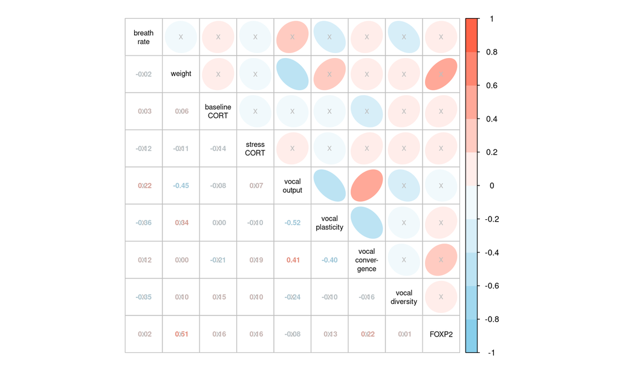

```r
day3_agg$ID <- NULL

corr_mat <- cor(day3_agg, use = "pairwise.complete.obs")

pvalue_mat <- corr_mat
pvalue_mat <- pvalue_mat * NA

for (i in colnames(pvalue_mat)) {
    for (e in rownames(pvalue_mat)) {

        if (sum(complete.cases(day3_agg[, i], day3_agg[, e])) > 2)
            ct <- cor.test(x = day3_agg[, i], y = day3_agg[, e], method = "pearson",
                use = "pairwise.complete.obs")$p.value else ct <- NA
        pvalue_mat[i, e] <- ct
        pvalue_mat[e, i] <- ct
    }
}
n_mat <- corr_mat
n_mat <- n_mat * NA

for (i in colnames(pvalue_mat)) {
    for (e in rownames(pvalue_mat)) {
        n_mat[i, e] <- sum(complete.cases(day3_agg[, i], day3_agg[,
            e]))
    }
}


# write.csv(pm, './output/parameters_correlation_pvalues.csv',
# row.names = TRUE) write.csv(pm2, './output/sample_sizes.csv',
# row.names = TRUE)

# make color scale
colorrange <- colorRampPalette(c("skyblue", "white", "tomato"))(10)
colorrange2 <- colorRampPalette(c("skyblue", "gray", "tomato"))(10)


rownames(corr_mat) <- colnames(corr_mat) <- names(day3_agg) <- c("breath\nrate",
    "weight", "baseline\nCORT", "stress\nCORT", "vocal\noutput", "vocal\nplasticity",
    "vocal\nconver-\ngence", "vocal\ndiversity", "FOXP2")

# jpeg('./output/parameters_correlation_matrix.jpg', width =
# 1800, height = 1800, res = 300)

corrplot.mixed(corr_mat, p.mat = pvalue_mat, sig.level = 0.05, insig = "pch",
    pch = "x", pch.col = "gray", pch.cex = 0.9, upper = "ellipse",
    lower = "number", tl.col = "black", tl.srt = 45, number.cex = 0.7,
    tl.cex = 0.7, order = "original", mar = c(1, 1, 1, 1), upper.col = colorrange,
    lower.col = colorrange2)
```

```r
# dev.off()

print("p values:")
```

```
## [1] "p values:"
```

```r
data_table(pvalue_mat, 4)
```

|  | breath.rate | weight | baseline.CORT | stress.CORT | call.count | acustic.plasticity | acoustic.convergence | acoustic.diversity | ...foxp2 |
| --- | --- | --- | --- | --- | --- | --- | --- | --- | --- |
| breath.rate | 0 | 0.9174728212026713 | 0.8655580000508694 | 0.5456074875223578 | 0.2466176359521879 | 0.0816671638038718 | 0.548552869960073 | 0.08378367043279454 | 0.9604151026643748 |
| weight | 0.9174728212026713 | 7.230709203712951e-213 | 0.7756688204610577 | 0.5676541939857072 | 0.01480534935983637 | 0.1090533254278881 | 0.9874059309353045 | 0.6134183837983572 | 0.08727139919799087 |
| baseline.CORT | 0.8655580000508694 | 0.7756688204610577 | 0 | 0.4770718644570003 | 0.6804575739956582 | 0.9829938224503717 | 0.2852099430792617 | 0.4621567177952309 | 0.5961574395325112 |
| stress.CORT | 0.5456074875223578 | 0.5676541939857072 | 0.4770718644570003 | 0 | 0.7261825791673147 | 0.6269895664860798 | 0.3311995292516918 | 0.6157607635060094 | 0.6238816479660501 |
| call.count | 0.2466176359521879 | 0.01480534935983637 | 0.6804575739956582 | 0.7261825791673147 | 0 | 0.007837570407875626 | 0.01856267962897121 | 0.1954374986108451 | 0.7822129249736237 |
| acustic.plasticity | 0.0816671638038718 | 0.1090533254278881 | 0.9829938224503717 | 0.6269895664860798 | 0.007837570407875626 | 0 | 0.047358071934512 | 0.6461088091201644 | 0.711399395835813 |
| acoustic.convergence | 0.548552869960073 | 0.9874059309353045 | 0.2852099430792617 | 0.3311995292516918 | 0.01856267962897121 | 0.047358071934512 | 0 | 0.3933940642910077 | 0.4515407232299135 |
| acoustic.diversity | 0.08378367043279454 | 0.6134183837983572 | 0.4621567177952309 | 0.6157607635060094 | 0.1954374986108451 | 0.6461088091201644 | 0.3933940642910077 | 0 | 0.9832160635053737 |
| ...foxp2 | 0.9604151026643748 | 0.08727139919799087 | 0.5961574395325112 | 0.6238816479660501 | 0.7822129249736237 | 0.711399395835813 | 0.4515407232299135 | 0.9832160635053737 | 0 |

```r
print("sample sizes:")
```

```
## [1] "sample sizes:"
```

```r
data_table(n_mat, 0)
```

|  | breath.rate | weight | baseline.CORT | stress.CORT | call.count | acustic.plasticity | acoustic.convergence | acoustic.diversity | ...foxp2 |
| --- | --- | --- | --- | --- | --- | --- | --- | --- | --- |
| breath.rate | 29 | 29 | 29 | 29 | 29 | 24 | 27 | 26 | 12 |
| weight | 29 | 29 | 29 | 29 | 29 | 24 | 27 | 26 | 12 |
| baseline.CORT | 29 | 29 | 30 | 29 | 30 | 25 | 28 | 27 | 13 |
| stress.CORT | 29 | 29 | 29 | 29 | 29 | 24 | 27 | 26 | 12 |
| call.count | 29 | 29 | 30 | 29 | 35 | 25 | 32 | 31 | 15 |
| acustic.plasticity | 24 | 24 | 25 | 24 | 25 | 25 | 25 | 25 | 10 |
| acoustic.convergence | 27 | 27 | 28 | 27 | 32 | 25 | 32 | 31 | 14 |
| acoustic.diversity | 26 | 26 | 27 | 26 | 31 | 25 | 31 | 31 | 13 |
| ...foxp2 | 12 | 12 | 13 | 12 | 15 | 10 | 14 | 13 | 15 |

### Day 4

```r
day4_agg <- agg_dat[agg_dat$week == 4, c("ID", "breath.rate", "weight",
    "baseline.CORT", "stress.CORT", "call.count", "acustic.plasticity",
    "acoustic.convergence", "acoustic.diversity", "foxp2")]

print("Raw data:")
```

[1] “Raw data:”

```r
data_table(day4_agg)
```

|  | ID | breath.rate | weight | baseline.CORT | stress.CORT | call.count | acustic.plasticity | acoustic.convergence | acoustic.diversity | foxp2 |
| --- | --- | --- | --- | --- | --- | --- | --- | --- | --- | --- |
| 103 | 160YGHM |  |  |  |  | 1 |  |  |  | 0.929215 |
| 104 | 262YGHM |  |  |  |  | 19 |  | 0.7304647639141642 | 0.003627347182845183 |  |
| 105 | 270YGHM | -132 | -3 | 15.8028 | 10.7765 | 1 |  |  |  |  |
| 106 | 300YGHM | -124 | -6 | -1.1105 | -10.3523 | 2 |  |  |  | 0.731717 |
| 107 | 303YGHM |  |  |  |  | 1 |  |  |  | 1.448696 |
| 108 | 327YYLM | -112 | 0 | 12.8697 | -21.2042 | 8 | 0.8853043309393469 | 0.08824540429842648 | 0.004760871002499494 |  |
| 109 | 360YGHM | -82 | -12 | 15.5087 | -64.6692 | 299 | 0.2143257169309006 | 0.6015809182590172 | 0.001641275030226275 |  |
| 110 | 361YGHM | -96 | -4 | 19.3764 | 8.418399999999998 | 73 | 0.2924124478817258 | 0.5974582656489063 | 0.002736704047603977 |  |
| 111 | 371YYLM | -88 | -2 | 9.215 | -13.4207 | 9 | 0.4074386461742898 | 0.1971683185579327 | 0.01711833101649307 | 0.808994 |
| 112 | 377WWLM | -110 | -2 | -1.348599999999999 | -11.7947 | 15 | 0.9236401559791806 | 0.43369520567443 | 0.006122433437852252 | 1.197626 |

[output cut: 17 more lines]

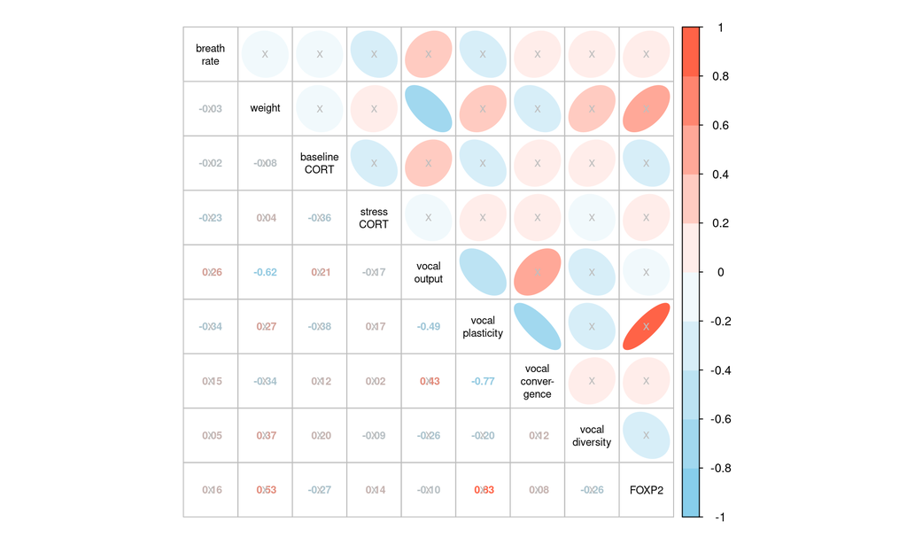

```r
day4_agg$ID <- NULL

corr_mat <- cor(day4_agg, use = "pairwise.complete.obs")

pvalue_mat <- corr_mat
pvalue_mat <- pvalue_mat * NA

for (i in colnames(pvalue_mat)) {
    for (e in rownames(pvalue_mat)) {

        ct <- cor.test(x = day4_agg[, i], y = day4_agg[, e], method = "pearson",
            use = "pairwise.complete.obs")$p.value

        pvalue_mat[i, e] <- ct
        pvalue_mat[e, i] <- ct
    }
}
n_mat <- corr_mat
n_mat <- n_mat * NA

for (i in colnames(pvalue_mat)) {
    for (e in rownames(pvalue_mat)) {
        n_mat[i, e] <- sum(complete.cases(day4_agg[, i], day4_agg[,
            e]))
    }
}


# write.csv(pm, './output/parameters_correlation_pvalues.csv',
# row.names = TRUE) write.csv(pm2, './output/sample_sizes.csv',
# row.names = TRUE)

# make color scale
colorrange <- colorRampPalette(c("skyblue", "white", "tomato"))(10)
colorrange2 <- colorRampPalette(c("skyblue", "gray", "tomato"))(10)


rownames(corr_mat) <- colnames(corr_mat) <- names(day4_agg) <- c("breath\nrate",
    "weight", "baseline\nCORT", "stress\nCORT", "vocal\noutput", "vocal\nplasticity",
    "vocal\nconver-\ngence", "vocal\ndiversity", "FOXP2")

# jpeg('./output/parameters_correlation_matrix.jpg', width =
# 1800, height = 1800, res = 300)

corrplot.mixed(corr_mat, p.mat = pvalue_mat, sig.level = 0.05, insig = "pch",
    pch = "x", pch.col = "gray", pch.cex = 0.9, upper = "ellipse",
    lower = "number", tl.col = "black", tl.srt = 45, number.cex = 0.7,
    tl.cex = 0.7, order = "original", mar = c(1, 1, 1, 1), upper.col = colorrange,
    lower.col = colorrange2)
```

```r
# dev.off()

print("p values:")
```

[1] “p values:”

```r
data_table(pvalue_mat, 4)
```

|  | breath.rate | weight | baseline.CORT | stress.CORT | call.count | acustic.plasticity | acoustic.convergence | acoustic.diversity | foxp2 |
| --- | --- | --- | --- | --- | --- | --- | --- | --- | --- |
| breath.rate | 0 | 0.8868841907473306 | 0.9161124863168694 | 0.3036516524532101 | 0.2463055013570588 | 0.1833806918663533 | 0.5459808094434102 | 0.8501145351340748 | 0.7073614140662872 |
| weight | 0.8868841907473306 | 0 | 0.7376879318014371 | 0.8733450911837877 | 0.002177969061794205 | 0.2882428618496119 | 0.169802921076058 | 0.1315114712466159 | 0.1800810168645783 |
| baseline.CORT | 0.9161124863168694 | 0.7376879318014371 | 0 | 0.1020328437938291 | 0.3399776083292683 | 0.1373658410317191 | 0.6321011579281426 | 0.437298714631974 | 0.4798075112226506 |
| stress.CORT | 0.3036516524532101 | 0.8733450911837877 | 0.1020328437938291 | 0 | 0.4621774271115762 | 0.5104726598030586 | 0.9231752793959427 | 0.7301611509401582 | 0.7407951267597341 |
| call.count | 0.2463055013570588 | 0.002177969061794205 | 0.3399776083292683 | 0.4621774271115762 | 0 | 0.04476582276469357 | 0.06709230922705152 | 0.276779351567882 | 0.7719571657835255 |
| acustic.plasticity | 0.1833806918663533 | 0.2882428618496119 | 0.1373658410317191 | 0.5104726598030586 | 0.04476582276469357 | 1.454414456122652e-116 | 0.0002756181428681452 | 0.4400191318878514 | 0.08512982582391852 |
| acoustic.convergence | 0.5459808094434102 | 0.169802921076058 | 0.6321011579281426 | 0.9231752793959427 | 0.06709230922705152 | 0.0002756181428681452 | 0 | 0.6137940396990482 | 0.8842318981552986 |
| acoustic.diversity | 0.8501145351340748 | 0.1315114712466159 | 0.437298714631974 | 0.7301611509401582 | 0.276779351567882 | 0.4400191318878514 | 0.6137940396990482 | 0 | 0.6183300415581927 |
| foxp2 | 0.7073614140662872 | 0.1800810168645783 | 0.4798075112226506 | 0.7407951267597341 | 0.7719571657835255 | 0.08512982582391852 | 0.8842318981552986 | 0.6183300415581927 | 0 |

```r
print("sample sizes:")
```

[1] “sample sizes:”

```r
data_table(n_mat, 0)
```

|  | breath.rate | weight | baseline.CORT | stress.CORT | call.count | acustic.plasticity | acoustic.convergence | acoustic.diversity | foxp2 |
| --- | --- | --- | --- | --- | --- | --- | --- | --- | --- |
| breath.rate | 22 | 22 | 22 | 22 | 22 | 17 | 18 | 18 | 8 |
| weight | 22 | 22 | 22 | 22 | 22 | 17 | 18 | 18 | 8 |
| baseline.CORT | 22 | 22 | 23 | 22 | 23 | 17 | 18 | 18 | 9 |
| stress.CORT | 22 | 22 | 22 | 22 | 22 | 17 | 18 | 18 | 8 |
| call.count | 22 | 22 | 23 | 22 | 27 | 17 | 19 | 19 | 11 |
| acustic.plasticity | 17 | 17 | 17 | 17 | 17 | 17 | 17 | 17 | 5 |
| acoustic.convergence | 18 | 18 | 18 | 18 | 19 | 17 | 19 | 19 | 6 |
| acoustic.diversity | 18 | 18 | 18 | 18 | 19 | 17 | 19 | 19 | 6 |
| foxp2 | 8 | 8 | 9 | 8 | 11 | 5 | 6 | 6 | 11 |

### Day 3 and 4

Averaged across the 2 weeks, excluding NAs

```r
day34_agg <- agg_dat[agg_dat$week %in% 3:4, c("ID", "breath.rate",
    "weight", "baseline.CORT", "stress.CORT", "call.count", "acustic.plasticity",
    "acoustic.convergence", "acoustic.diversity", "...foxp2")]

print("Raw data:")
```

[1] “Raw data:”

```r
data_table(day34_agg)
```

|  | ID | breath.rate | weight | baseline.CORT | stress.CORT | call.count | acustic.plasticity | acoustic.convergence | acoustic.diversity | ...foxp2 |
| --- | --- | --- | --- | --- | --- | --- | --- | --- | --- | --- |
| 68 | 125YGHM |  |  |  |  | 2 |  |  |  |  |
| 69 | 160YGHM |  |  |  |  | 10 |  | 0.4075450952750787 | 0.00555620435305257 | 0.929215 |
| 70 | 258YGHM | -112 | 0 | 4.4147 | -0.2176000000000009 | 5 |  | 0.184460359771205 |  | 0.939208 |
| 71 | 262YGHM |  |  |  |  | 151 |  | 0.8746330868360347 | 0.003501077742245457 |  |
| 72 | 270YGHM | -132 | -3 | 7.899699999999999 | 0.7667999999999999 | 9 | 0.8029454412627713 | 0.2668303821062505 | 0.006690487674346999 |  |
| 73 | 300YGHM | -122 | -4 | -7.309 | -14.8944 | 8 | 0.4925827989279387 | 0.1688928494749423 | 0.00963116595670391 | 0.731717 |
| 74 | 303YGHM |  |  |  |  | 15 |  | 0.4518677998590173 | 0.0112914388782704 | 1.448696 |
| 75 | 310YGHM | -98 | -4 | -5.568300000000001 | -6.0579 | 3 |  |  |  | 0.761613 |
| 76 | 327YYLM | -113 | -1 | 7.5639 | -18.5388 | 220 | 0.6394607352983404 | 0.7195323376435994 | 0.002253671801999801 |  |
| 77 | 356WBHM | -88 | -3 | -18.0567 | -3.976600000000005 | 227 | 0.2627406323499795 | 0.652527038340113 | 0.001546532934601505 | 0.866813 |

[output cut: 52 more lines]

```r
day34_agg <- aggregate(day34_agg[, -1], by = list(ID = day34_agg$ID),
    FUN = mean, na.rm = TRUE)

print("Averaged data:")
```

[1] “Averaged data:”

```r
data_table(day34_agg)
```

|  | ID | breath.rate | weight | baseline.CORT | stress.CORT | call.count | acustic.plasticity | acoustic.convergence | acoustic.diversity | ...foxp2 |
| --- | --- | --- | --- | --- | --- | --- | --- | --- | --- | --- |
| 1 | 125YGHM |  |  |  |  | 2 |  |  |  |  |
| 2 | 160YGHM |  |  |  |  | 5.5 |  | 0.4075450952750787 | 0.00555620435305257 | 0.929215 |
| 3 | 258YGHM | -112 | 0 | 4.4147 | -0.2176000000000009 | 5 |  | 0.184460359771205 |  | 0.939208 |
| 4 | 262YGHM |  |  |  |  | 85 |  | 0.8025489253750995 | 0.00356421246254532 |  |
| 5 | 270YGHM | -132 | -3 | 11.85125 | 5.771649999999999 | 5 | 0.8029454412627713 | 0.2668303821062505 | 0.006690487674346999 |  |
| 6 | 300YGHM | -123 | -5 | -4.20975 | -12.62335 | 5 | 0.4925827989279387 | 0.1688928494749423 | 0.00963116595670391 | 0.731717 |
| 7 | 303YGHM |  |  |  |  | 8 |  | 0.4518677998590173 | 0.0112914388782704 | 1.448696 |
| 8 | 310YGHM | -98 | -4 | -5.568300000000001 | -6.0579 | 3 |  |  |  | 0.761613 |
| 9 | 327YYLM | -112.5 | -0.5 | 10.2168 | -19.8715 | 114 | 0.7623825331188436 | 0.4038888709710129 | 0.003507271402249648 |  |
| 10 | 356WBHM | -88 | -3 | -18.0567 | -3.976600000000005 | 227 | 0.2627406323499795 | 0.652527038340113 | 0.001546532934601505 | 0.866813 |

[output cut: 25 more lines]

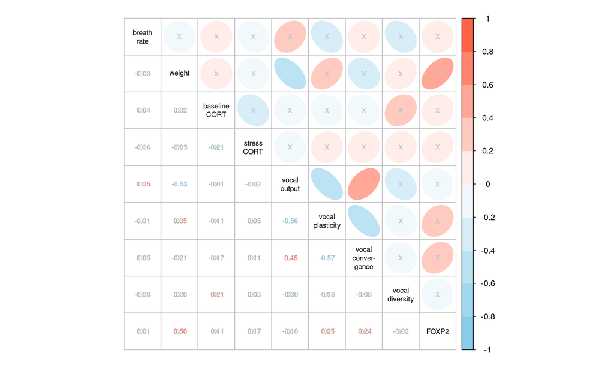

```r
day34_agg$ID <- NULL

corr_mat <- cor(day34_agg, use = "pairwise.complete.obs")

pvalue_mat <- corr_mat
pvalue_mat <- pvalue_mat * NA

for (i in colnames(pvalue_mat)) {
    for (e in rownames(pvalue_mat)) {

        ct <- cor.test(x = day34_agg[, i], y = day34_agg[, e], method = "pearson",
            use = "pairwise.complete.obs")$p.value

        pvalue_mat[i, e] <- ct
        pvalue_mat[e, i] <- ct
    }
}
n_mat <- corr_mat
n_mat <- n_mat * NA

for (i in colnames(pvalue_mat)) {
    for (e in rownames(pvalue_mat)) {
        n_mat[i, e] <- sum(complete.cases(day34_agg[, i], day34_agg[,
            e]))
    }
}


# write.csv(pm, './output/parameters_correlation_pvalues.csv',
# row.names = TRUE) write.csv(pm2, './output/sample_sizes.csv',
# row.names = TRUE)

# make color scale
colorrange <- colorRampPalette(c("skyblue", "white", "tomato"))(10)
colorrange2 <- colorRampPalette(c("skyblue", "gray", "tomato"))(10)


rownames(corr_mat) <- colnames(corr_mat) <- names(day34_agg) <- c("breath\nrate",
    "weight", "baseline\nCORT", "stress\nCORT", "vocal\noutput", "vocal\nplasticity",
    "vocal\nconver-\ngence", "vocal\ndiversity", "FOXP2")

# jpeg('./output/parameters_correlation_matrix.jpg', width =
# 1800, height = 1800, res = 300)

corrplot.mixed(corr_mat, p.mat = pvalue_mat, sig.level = 0.05, insig = "pch",
    pch = "x", pch.col = "gray", pch.cex = 0.9, upper = "ellipse",
    lower = "number", tl.col = "black", tl.srt = 45, number.cex = 0.7,
    tl.cex = 0.7, order = "original", mar = c(1, 1, 1, 1), upper.col = colorrange,
    lower.col = colorrange2)
```

```r
# dev.off()

print("p values:")
```

[1] “p values:”

```r
data_table(pvalue_mat, 4)
```

|  | breath.rate | weight | baseline.CORT | stress.CORT | call.count | acustic.plasticity | acoustic.convergence | acoustic.diversity | ...foxp2 |
| --- | --- | --- | --- | --- | --- | --- | --- | --- | --- |
| breath.rate | 0 | 0.8759274915118633 | 0.8316710404057649 | 0.4032897608813465 | 0.1850519703047099 | 0.141165509733861 | 0.8204595376158725 | 0.1643235002390879 | 0.9707332336534996 |
| weight | 0.8759274915118633 | 8.376948343984638e-209 | 0.9288529699907715 | 0.7906246613254047 | 0.003310767343820532 | 0.09031498294039768 | 0.2827689673652607 | 0.3302379482143688 | 0.1016458806856538 |
| baseline.CORT | 0.8316710404057649 | 0.9288529699907715 | 1.734072837471911e-216 | 0.2678114036106609 | 0.9475264145499729 | 0.596340287883802 | 0.3748685640422583 | 0.2920389471304267 | 0.7249008384221801 |
| stress.CORT | 0.4032897608813465 | 0.7906246613254047 | 0.2678114036106609 | 0 | 0.9295565545122221 | 0.815864205875076 | 0.5810577079254717 | 0.8184927459887394 | 0.6003138667590842 |
| call.count | 0.1850519703047099 | 0.003310767343820532 | 0.9475264145499729 | 0.9295565545122221 | 0 | 0.003266335835568316 | 0.01065202281433509 | 0.1028198716674832 | 0.7218901223365725 |
| acustic.plasticity | 0.141165509733861 | 0.09031498294039768 | 0.596340287883802 | 0.815864205875076 | 0.003266335835568316 | 1.586425303066468e-181 | 0.002712365132294422 | 0.4536494370527245 | 0.4949633009437574 |
| acoustic.convergence | 0.8204595376158725 | 0.2827689673652607 | 0.3748685640422583 | 0.5810577079254717 | 0.01065202281433509 | 0.002712365132294422 | 0 | 0.6882395209016434 | 0.4080111086709332 |
| acoustic.diversity | 0.1643235002390879 | 0.3302379482143688 | 0.2920389471304267 | 0.8184927459887394 | 0.1028198716674832 | 0.4536494370527245 | 0.6882395209016434 | 0 | 0.9383397090882206 |
| ...foxp2 | 0.9707332336534996 | 0.1016458806856538 | 0.7249008384221801 | 0.6003138667590842 | 0.7218901223365725 | 0.4949633009437574 | 0.4080111086709332 | 0.9383397090882206 | 0 |

```r
print("sample sizes:")
```

[1] “sample sizes:”

```r
data_table(n_mat, 0)
```

|  | breath.rate | weight | baseline.CORT | stress.CORT | call.count | acustic.plasticity | acoustic.convergence | acoustic.diversity | ...foxp2 |
| --- | --- | --- | --- | --- | --- | --- | --- | --- | --- |
| breath.rate | 29 | 29 | 29 | 29 | 29 | 24 | 27 | 26 | 12 |
| weight | 29 | 29 | 29 | 29 | 29 | 24 | 27 | 26 | 12 |
| baseline.CORT | 29 | 29 | 30 | 29 | 30 | 25 | 28 | 27 | 13 |
| stress.CORT | 29 | 29 | 29 | 29 | 29 | 24 | 27 | 26 | 12 |
| call.count | 29 | 29 | 30 | 29 | 35 | 25 | 32 | 31 | 15 |
| acustic.plasticity | 24 | 24 | 25 | 24 | 25 | 25 | 25 | 25 | 10 |
| acoustic.convergence | 27 | 27 | 28 | 27 | 32 | 25 | 32 | 31 | 14 |
| acoustic.diversity | 26 | 26 | 27 | 26 | 31 | 25 | 31 | 31 | 13 |
| ...foxp2 | 12 | 12 | 13 | 12 | 15 | 10 | 14 | 13 | 15 |

# Physiological parameters

Barplot and effect sizes graph

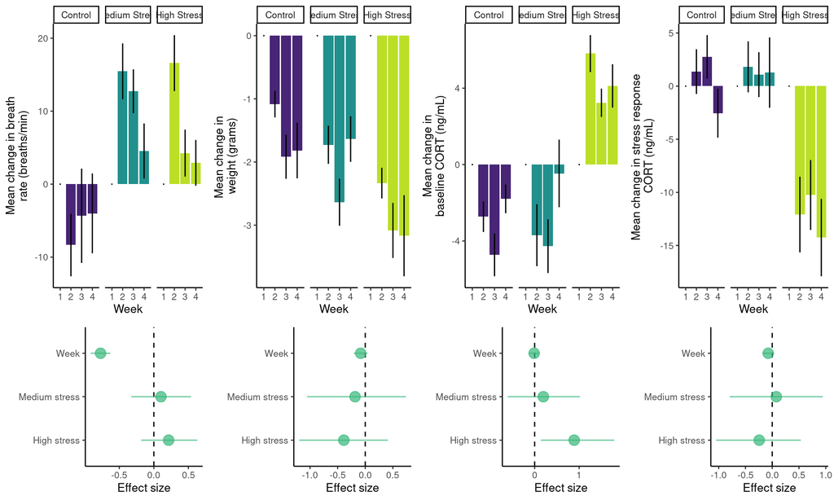

```r
physio_models <- readRDS("./data/processed/physiological_response_models.RDS")

breath.count <- stack(metadat[, c("D3.Breath.Count", "D7.Breath.Count",
    "D14.Breath.Count", "D21.Breath.Count", "D28.Breath.Count")])

weight <- stack(metadat[, c("D3.Bird.Weight..g.", "D7.Bird.Weight..g.",
    "D14.Bird.Weight..g.", "D21.Bird.Weight..g.", "D28.Bird.Weight..g.")])

cort.stress <- stack(metadat[, c("D3.CORT.Stress", "D7.CORT.Stress",
    "D14.CORT.Stress", "D21.CORT.Stress", "D28.CORT.Stress")])

cort.baseline <- stack(metadat[, c("D3.CORT.Baseline", "D7.CORT.Baseline",
    "D14.CORT.Baseline", "D21.CORT.Baseline", "D28.CORT.Baseline")])


stress <- data.frame(metadat[, c("Bird.ID", "Treatment", "Round",
    "Treatment.Room")], week = breath.count$ind, breath.count = breath.count$values,
    weight = weight$values, cort.stress = cort.stress$values, cort.baseline = cort.baseline$values,
    stress.response = cort.stress$values - cort.baseline$values)

# head(stress)

stress$week <- factor(sapply(strsplit(as.character(stress$week), "\\."),
    "[[", 1), levels = c("D3", "D7", "D14", "D21", "D28"))

stress$day <- as.numeric(gsub("D", "", as.character(stress$week)))
stress$round <- paste("Round", stress$Round)

stress$treatment <- factor(stress$Treatment, levels = c("Control",
    "Medium Stress", "High Stress"))

# remove 5th week
stress <- stress[stress$week != "D28", ]


stress_l <- lapply(stress$Bird.ID, function(x) {
    X <- stress[stress$Bird.ID == x, ]

    X$breath.count <- X$breath.count - X$breath.count[X$week == "D3"]
    X$weight <- X$weight - X$weight[X$week == "D3"]
    X$cort.stress <- X$cort.stress - X$cort.stress[X$week == "D3"]
    X$cort.baseline <- X$cort.baseline - X$cort.baseline[X$week ==
        "D3"]
    X$stress.response <- X$stress.response - X$stress.response[X$week ==
        "D3"]

    return(X)
})

stress <- do.call(rbind, stress_l)

agg_stress <- aggregate(cbind(breath.count, weight, stress.response,
    cort.baseline) ~ week + treatment, stress, mean)
agg_stress_se <- aggregate(cbind(breath.count, weight, stress.response,
    cort.baseline) ~ week + treatment, stress, standard_error)

names(agg_stress_se) <- paste(names(agg_stress_se), ".se", sep = "")

agg_stress <- cbind(agg_stress, agg_stress_se[, 3:6])

agg_stress$Week <- 1:4

bs <- 10

gg_breath.count <- ggplot(data = agg_stress, aes(x = Week, y = breath.count,
    fill = treatment)) + geom_bar(stat = "identity") + geom_errorbar(aes(ymin = breath.count -
    breath.count.se, ymax = breath.count + breath.count.se), width = 0.1) +
    scale_fill_viridis_d(begin = 0.1, end = 0.9) + facet_wrap(~treatment,
    ncol = 3, scale = "fixed") + labs(y = "Mean change in breath\nrate (breaths/min)",
    x = "Week") + theme_classic(base_size = bs) + theme(legend.position = "none")

gg_weight <- ggplot(data = agg_stress, aes(x = Week, y = weight, fill = treatment)) +
    geom_bar(stat = "identity") + geom_errorbar(aes(ymin = weight -
    weight.se, ymax = weight + weight.se), width = 0.1) + scale_fill_viridis_d(begin = 0.1,
    end = 0.9) + facet_wrap(~treatment, ncol = 3, scale = "fixed") +
    labs(y = "Mean change in \nweight (grams)", x = "Week") + theme_classic(base_size = bs) +
    theme(legend.position = "none")


gg_cort.baseline <- ggplot(data = agg_stress, aes(x = Week, y = cort.baseline,
    fill = treatment)) + geom_bar(stat = "identity") + geom_errorbar(aes(ymin = cort.baseline -
    cort.baseline.se, ymax = cort.baseline + cort.baseline.se), width = 0.1) +
    scale_fill_viridis_d(begin = 0.1, end = 0.9) + facet_wrap(~treatment,
    ncol = 3, scale = "fixed") + labs(y = "Mean change in\nbaseline CORT (ng/mL)",
    x = "Week") + theme_classic(base_size = bs) + theme(legend.position = "none")


gg_stress.response <- ggplot(data = agg_stress, aes(x = Week, y = stress.response,
    fill = treatment)) + geom_bar(stat = "identity") + geom_errorbar(aes(ymin = stress.response -
    stress.response.se, ymax = stress.response + stress.response.se),
    width = 0.1) + scale_fill_viridis_d(begin = 0.1, end = 0.9) +
    facet_wrap(~treatment, ncol = 3, scale = "fixed") + labs(y = "Mean change in stress response \nCORT (ng/mL)",
    x = "Week") + theme_classic(base_size = bs) + theme(legend.position = "none")


gg_coeffs_physio <- lapply(physio_models, function(x) {

    vars <- grep("b_", posterior::variables(x), value = TRUE)
    draws <- posterior::as_draws_array(x, variable = vars)

    coef_table <- draw_summary(draws, variables = vars, probs = c(0.025,
        0.975), robust = TRUE, spread.type = "HPDI")

    coef_table$predictor <- rownames(coef_table)
    coef_table$predictor <- gsub("b_treatment|b_", "", coef_table$predictor)
    coef_table$predictor <- gsub("Stress", " stress", coef_table$predictor)
    coef_table$predictor <- gsub("week", "Week", coef_table$predictor)
    coef_table <- coef_table[coef_table$predictor != "Intercept",
        ]

    gg_coef <- ggplot2::ggplot(data = coef_table, aes(x = Estimate,
        y = predictor)) + geom_vline(xintercept = 0, lty = 2) + ggplot2::geom_point(size = 4,
        col = col_pointrange) + ggplot2::geom_errorbar(ggplot2::aes(xmin = `l-95% CI`,
        xmax = `u-95% CI`), width = 0, col = col_pointrange) + ggplot2::theme_classic(base_size = bs) +
        ggplot2::theme(axis.ticks.length = ggplot2::unit(0, "pt"),
            plot.margin = ggplot2::margin(0, 0, 0, 0, "pt"), legend.position = "none",
            strip.background = ggplot2::element_blank(), strip.text = ggplot2::element_blank()) +
        ggplot2::labs(x = "Effect size", y = "")

    return(gg_coef)
})

cowplot::plot_grid(gg_breath.count, gg_weight, gg_cort.baseline, gg_stress.response,
    gg_coeffs_physio[[grep("breath", names(gg_coeffs_physio))]] +
        theme_classic(base_size = bs), gg_coeffs_physio[[grep("weight",
        names(gg_coeffs_physio))]] + theme_classic(base_size = bs),
    gg_coeffs_physio[[grep("baseline", names(gg_coeffs_physio))]] +
        theme_classic(base_size = bs), gg_coeffs_physio[[grep("response",
        names(gg_coeffs_physio))]] + theme_classic(base_size = bs),
    nrow = 2, rel_heights = c(1.8, 1))
```

```r
# try bs = 20 for saving plots

# cowplot::ggsave2(filename =
# './output/bar_graphs_and_estimates_physiology_70dpi.jpeg',
# width = 25, height = 9) cowplot::ggsave2(filename =
# './output/bar_graphs_and_estimates_physiology_300dpi.jpeg',
# dpi = 300, width = 25, height = 9)
```

## Stats

Models: Predicted physio measure ~ treatment + week (continuous) + IndRandom

Variables (Difference from Week 1): weight, BR, baseline CORT, Stress CORT, Stress Response

```r
responses <- c("baseline.CORT", "stress.response", "stress.CORT",
    "weight", "breath.rate")

predictors <- c("~ treatment + week + (1|ID) + (1|round)")

formulas <- expand.grid(responses = responses, predictors = predictors,
    stringsAsFactors = FALSE)

vars_to_scale <- c(responses, "week")

# remove week 1
sub_agg_dat <- agg_dat[agg_dat$week != 1, ]

for (i in vars_to_scale) sub_agg_dat[, vars_to_scale] <- scale(sub_agg_dat[,
    vars_to_scale])

physio_models <- lapply(1:nrow(formulas), function(x) {

    sub_dat <- sub_agg_dat[!is.na(sub_agg_dat[names(sub_agg_dat) ==
        formulas$responses[x]]), ]
    sub_dat
    # replace ~ by 'by' in the formula
    mod_name <- paste(formulas$responses[x], gsub("~", "by", formulas$predictors[x]))

    mod <- brm(formula = paste(formulas$responses[x], formulas$predictors[x]),
        iter = 50000, silent = 2, data = sub_dat, control = list(adapt_delta = 0.9,
            max_treedepth = 15), chains = 4, cores = 4, file = paste0("./data/processed/updated_regressions/physio-",
            mod_name), file_refit = "always", prior = c(prior(normal(0,
            5), "b"), prior(normal(0, 10), "Intercept"), prior(student_t(3,
            0, 10), "sd"), prior(student_t(3, 0, 10), "sigma")))

    return(mod)
})
```

```r
physio_models <- list.files("./data/processed/updated_regressions",
    pattern = "physio-", full.names = TRUE)

for (x in 1:length(physio_models)) extended_summary(read.file = physio_models[x],
    gsub.pattern = "b_treatment|b_", gsub.replacement = "", highlight = TRUE,
    remove.intercepts = TRUE)
```

## physio-baseline.CORT by treatment + week + (1|ID) + (1|round)

|  | formula | family | priors | iterations | chains | thinning | warmup | diverg_transitions | rhats > 1.05 | min_bulk_ESS | min_tail_ESS | seed |
| --- | --- | --- | --- | --- | --- | --- | --- | --- | --- | --- | --- | --- |
| 1 | baseline.CORT ~ treatment + week + (1 \| ID) + (1 \| round) | gaussian (identity) | b-normal(0, 5) Intercept-normal(0, 10) sd-student_t(3, 0, 10) sigma-student_t(3, 0, 10) | 50000 | 4 | 1 | 25000 | 2088 (0.021%) | 0 | 17802.73 | 21269.94 | 824178344 |

|  | Estimate | l-95% CI | u-95% CI | Rhat | Bulk_ESS | Tail_ESS |
| --- | --- | --- | --- | --- | --- | --- |
| HighStress | 0.761 | 0.117 | 1.409 | 1 | 17802.73 | 21269.94 |
| MediumStress | 0.178 | -0.499 | 0.859 | 1 | 18629.89 | 33745.84 |
| week | -0.001 | -0.142 | 0.141 | 1 | 52049.02 | 38083.98 |

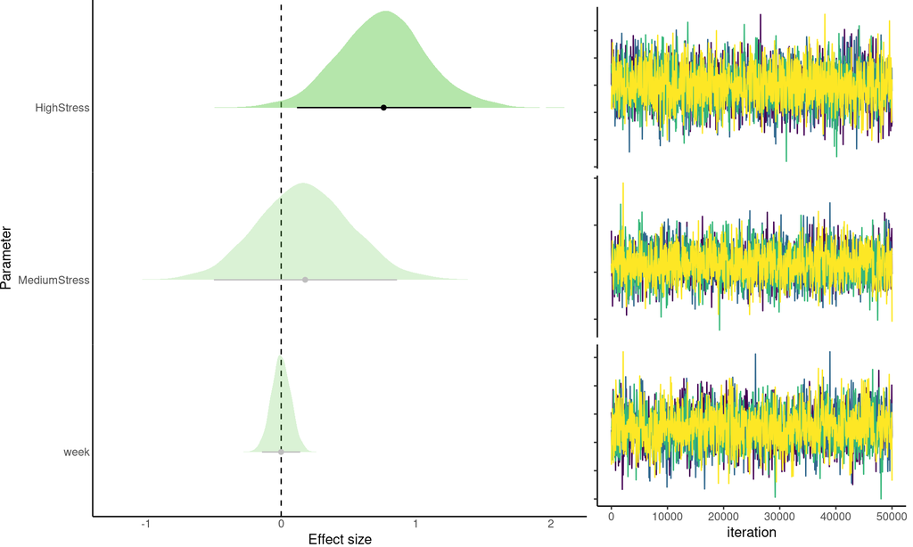

## physio-breath.rate by treatment + week + (1|ID) + (1|round)

|  | formula | family | priors | iterations | chains | thinning | warmup | diverg_transitions | rhats > 1.05 | min_bulk_ESS | min_tail_ESS | seed |
| --- | --- | --- | --- | --- | --- | --- | --- | --- | --- | --- | --- | --- |
| 1 | breath.rate ~ treatment + week + (1 \| ID) + (1 \| round) | gaussian (identity) | b-normal(0, 5) Intercept-normal(0, 10) sd-student_t(3, 0, 10) sigma-student_t(3, 0, 10) | 50000 | 4 | 1 | 25000 | 3008 (0.03%) | 0 | 6957.79 | 3542.086 | 289722089 |

|  | Estimate | l-95% CI | u-95% CI | Rhat | Bulk_ESS | Tail_ESS |
| --- | --- | --- | --- | --- | --- | --- |
| HighStress | 0.148 | -0.150 | 0.445 | 1 | 25316.859 | 18245.547 |
| MediumStress | 0.059 | -0.268 | 0.387 | 1 | 9115.117 | 38801.326 |
| week | -0.785 | -0.904 | -0.668 | 1.001 | 6957.790 | 3542.086 |

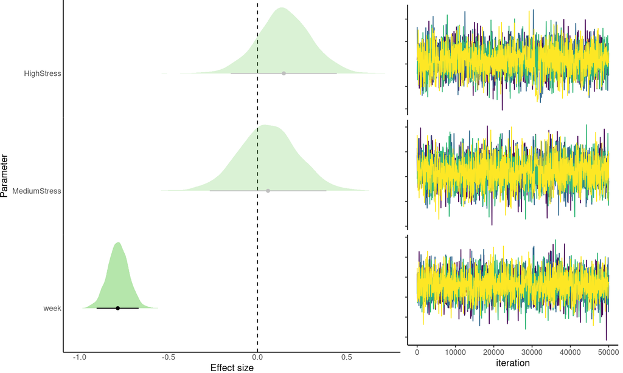

## physio-stress.CORT by treatment + week + (1|ID) + (1|round)

|  | formula | family | priors | iterations | chains | thinning | warmup | diverg_transitions | rhats > 1.05 | min_bulk_ESS | min_tail_ESS | seed |
| --- | --- | --- | --- | --- | --- | --- | --- | --- | --- | --- | --- | --- |
| 1 | stress.CORT ~ treatment + week + (1 \| ID) + (1 \| round) | gaussian (identity) | b-normal(0, 5) Intercept-normal(0, 10) sd-student_t(3, 0, 10) sigma-student_t(3, 0, 10) | 50000 | 4 | 1 | 25000 | 3672 (0.037%) | 0 | 2024.468 | 1701.296 | 14709470 |

|  | Estimate | l-95% CI | u-95% CI | Rhat | Bulk_ESS | Tail_ESS |
| --- | --- | --- | --- | --- | --- | --- |
| HighStress | -0.228 | -0.917 | 0.467 | 1.003 | 2024.468 | 1701.296 |
| MediumStress | 0.076 | -0.669 | 0.835 | 1.001 | 12813.145 | 16406.743 |
| week | -0.153 | -0.285 | -0.022 | 1.001 | 30511.600 | 30761.711 |

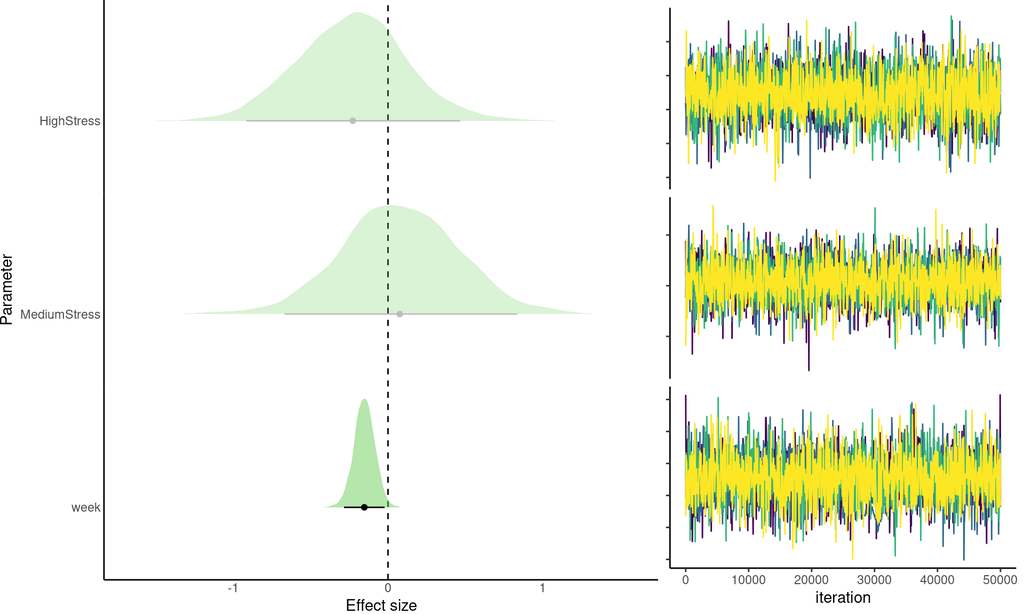

## physio-stress.response by treatment + week + (1|ID) + (1|round)

|  | formula | family | priors | iterations | chains | thinning | warmup | diverg_transitions | rhats > 1.05 | min_bulk_ESS | min_tail_ESS | seed |
| --- | --- | --- | --- | --- | --- | --- | --- | --- | --- | --- | --- | --- |
| 1 | stress.response ~ treatment + week + (1 \| ID) + (1 \| round) | gaussian (identity) | b-normal(0, 5) Intercept-normal(0, 10) sd-student_t(3, 0, 10) sigma-student_t(3, 0, 10) | 50000 | 4 | 1 | 25000 | 3566 (0.036%) | 0 | 3228.217 | 1459.202 | 1084725584 |

|  | Estimate | l-95% CI | u-95% CI | Rhat | Bulk_ESS | Tail_ESS |
| --- | --- | --- | --- | --- | --- | --- |
| HighStress | -0.218 | -0.918 | 0.480 | 1.002 | 3228.217 | 1459.202 |
| MediumStress | 0.079 | -0.684 | 0.834 | 1.001 | 10543.311 | 30704.128 |
| week | -0.154 | -0.286 | -0.021 | 1 | 9787.166 | 10517.359 |

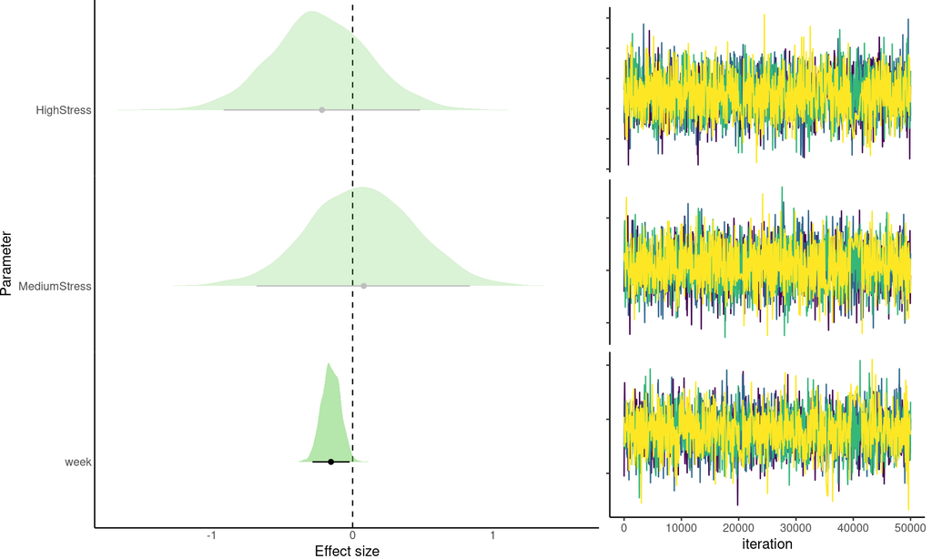

## physio-weight by treatment + week + (1|ID) + (1|round)

|  | formula | family | priors | iterations | chains | thinning | warmup | diverg_transitions | rhats > 1.05 | min_bulk_ESS | min_tail_ESS | seed |
| --- | --- | --- | --- | --- | --- | --- | --- | --- | --- | --- | --- | --- |
| 1 | weight ~ treatment + week + (1 \| ID) + (1 \| round) | gaussian (identity) | b-normal(0, 5) Intercept-normal(0, 10) sd-student_t(3, 0, 10) sigma-student_t(3, 0, 10) | 50000 | 4 | 1 | 25000 | 2418 (0.024%) | 0 | 10571.94 | 9908.59 | 1985484202 |

|  | Estimate | l-95% CI | u-95% CI | Rhat | Bulk_ESS | Tail_ESS |
| --- | --- | --- | --- | --- | --- | --- |
| HighStress | -0.316 | -0.972 | 0.349 | 1 | 16014.11 | 14603.68 |
| MediumStress | -0.129 | -0.857 | 0.597 | 1 | 10571.94 | 9908.59 |
| week | -0.344 | -0.479 | -0.209 | 1 | 22457.98 | 25413.38 |

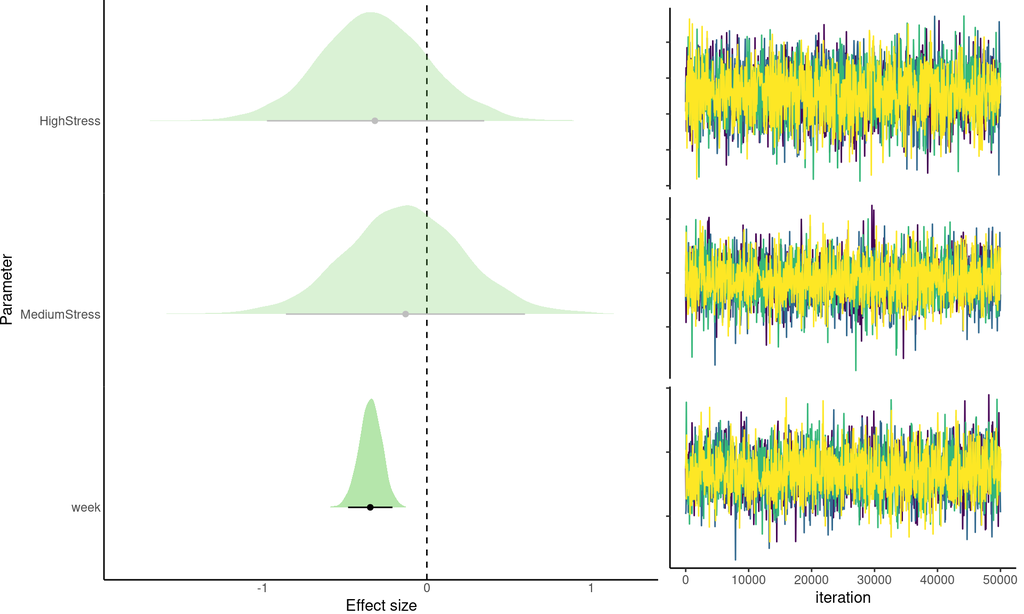

## Takeaways

- Breath rate decreases gradually across time after the first week
- Stress response is higher in “high stress” birds compared to first week

# Acoustic space projection

t-SNE

```r
scale_param <- scale(sels[, c("duration", "meanfreq", "sd", "freq.median",
    "freq.IQR", "time.IQR", "skew", "kurt", "sp.ent", "time.ent",
    "entropy", "meandom", "mindom", "maxdom", "dfrange", "modindx",
    "meanpeakf")])

tsne <- Rtsne(scale_param, dims = 2, perplexity = 30, verbose = FALSE,
    max_iter = 5000)

saveRDS(tsne, "./data/processed/tsne_on_acoustic_parameters_jun_2021.RDS")
```

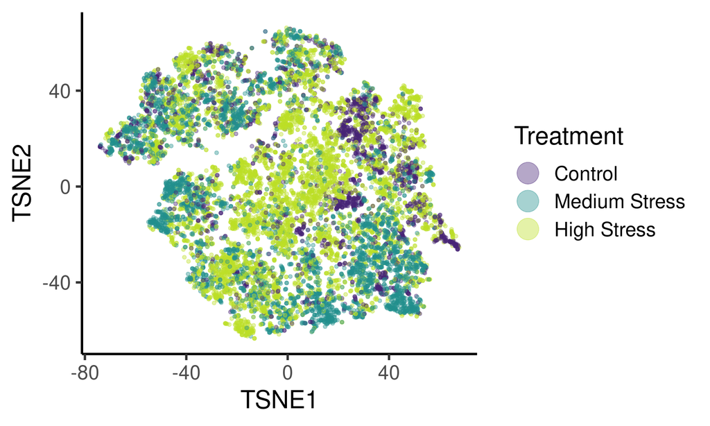

```r
tsne <- readRDS("./data/processed/tsne_on_acoustic_parameters_jun_2021.RDS")

Y <- as.data.frame(tsne$Y)
names(Y) <- c("TSNE1", "TSNE2")

sels <- data.frame(sels, Y)

sels$treatment <- factor(sels$treatment, levels = c("Control", "Medium Stress",
    "High Stress"))

ggplot(sels, aes(x = TSNE1, y = TSNE2, col = as.factor(treatment))) +
    geom_point() + labs(color = "Treatment") + scale_color_viridis_d(alpha = 0.4,
    begin = 0.1, end = 0.9) + theme_classic(base_size = 25) + guides(colour = guide_legend(override.aes = list(size = 10)))
```

# Behavioral parameters

Barplot and effect sizes pgrah

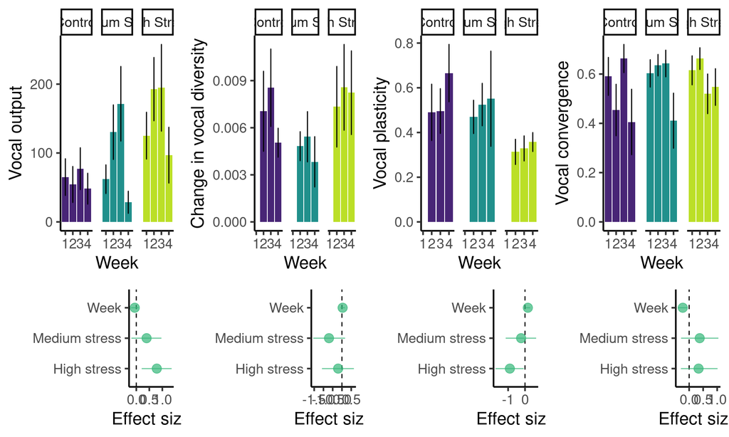

```r
behav_models <- readRDS("./data/processed/behavioral_response_models.RDS")

agg_call.count <- aggregate(cbind(call.count, acoustic.convergence) ~
    week + treatment, agg_dat, mean)

agg_behav <- aggregate(cbind(acoustic.diversity, acustic.plasticity) ~
    week + treatment, agg_dat, mean)

agg_call.count_se <- aggregate(cbind(call.count, acoustic.convergence) ~
    week + treatment, agg_dat, standard_error)

agg_behav_se <- aggregate(cbind(acoustic.diversity, acustic.plasticity) ~
    week + treatment, agg_dat, standard_error)

agg_behav_se <- merge(agg_call.count_se, agg_behav_se, all = TRUE)

names(agg_behav_se) <- paste(names(agg_behav_se), ".se", sep = "")

agg_behav <- merge(agg_call.count, agg_behav, all = TRUE)

agg_behav <- cbind(agg_behav, agg_behav_se[, 3:6])

bs <- 17

agg_behav$treatment <- factor(agg_behav$treatment, levels = c("Control",
    "Medium Stress", "High Stress"))

gg_call.count <- ggplot(data = agg_behav, aes(x = week, y = call.count,
    fill = treatment)) + geom_bar(stat = "identity") + geom_errorbar(aes(ymin = call.count -
    call.count.se, ymax = call.count + call.count.se), width = 0.1) +
    scale_fill_viridis_d(begin = 0.1, end = 0.9) + facet_wrap(~treatment,
    ncol = 3, scale = "fixed") + labs(y = "Vocal output", x = "Week") +
    theme_classic(base_size = bs) + theme(legend.position = "none")

gg_acoustic.diversity <- ggplot(data = agg_behav, aes(x = week, y = acoustic.diversity,
    fill = treatment)) + geom_bar(stat = "identity") + geom_errorbar(aes(ymin = acoustic.diversity -
    acoustic.diversity.se, ymax = acoustic.diversity + acoustic.diversity.se),
    width = 0.1) + scale_fill_viridis_d(begin = 0.1, end = 0.9) +
    facet_wrap(~treatment, ncol = 3, scale = "fixed") + labs(y = "Change in vocal diversity",
    x = "Week") + theme_classic(base_size = bs) + theme(legend.position = "none")

gg_acustic.plasticity <- ggplot(data = agg_behav, aes(x = week, y = acustic.plasticity,
    fill = treatment)) + geom_bar(stat = "identity") + geom_errorbar(aes(ymin = acustic.plasticity -
    acustic.plasticity.se, ymax = acustic.plasticity + acustic.plasticity.se),
    width = 0.1) + scale_fill_viridis_d(begin = 0.1, end = 0.9) +
    facet_wrap(~treatment, ncol = 3, scale = "fixed") + labs(y = "Vocal plasticity",
    x = "Week") + theme_classic(base_size = bs) + theme(legend.position = "none")

gg_acoustic.convergence <- ggplot(data = agg_behav, aes(x = week,
    y = acoustic.convergence, fill = treatment)) + geom_bar(stat = "identity") +
    geom_errorbar(aes(ymin = acoustic.convergence - acoustic.convergence.se,
        ymax = acoustic.convergence + acoustic.convergence.se), width = 0.1) +
    scale_fill_viridis_d(begin = 0.1, end = 0.9) + facet_wrap(~treatment,
    ncol = 3, scale = "fixed") + labs(y = "Vocal convergence", x = "Week") +
    theme_classic(base_size = bs) + theme(legend.position = "none")

gg_coeffs_behav <- lapply(behav_models, function(x) {

    vars <- grep("b_", posterior::variables(x), value = TRUE)
    draws <- posterior::as_draws_array(x, variable = vars)

    coef_table <- draw_summary(draws, variables = vars, probs = c(0.025,
        0.975), robust = TRUE, spread.type = "HPDI")

    coef_table$predictor <- rownames(coef_table)
    coef_table$predictor <- gsub("b_treatment|b_", "", coef_table$predictor)
    coef_table$predictor <- gsub("Stress", " stress", coef_table$predictor)
    coef_table$predictor <- gsub("week", "Week", coef_table$predictor)
    coef_table <- coef_table[coef_table$predictor != "Intercept",
        ]

    gg_coef <- ggplot2::ggplot(data = coef_table, aes(x = Estimate,
        y = predictor)) + geom_vline(xintercept = 0, lty = 2) + ggplot2::geom_point(size = 4,
        col = col_pointrange) + ggplot2::geom_errorbar(ggplot2::aes(xmin = `l-95% CI`,
        xmax = `u-95% CI`), width = 0, col = col_pointrange) + ggplot2::theme_classic(base_size = bs) +
        ggplot2::theme(axis.ticks.length = ggplot2::unit(0, "pt"),
            plot.margin = ggplot2::margin(0, 0, 0, 0, "pt"), legend.position = "none",
            strip.background = ggplot2::element_blank(), strip.text = ggplot2::element_blank()) +
        ggplot2::labs(x = "Effect size", y = "")

    return(gg_coef)
})

cowplot::plot_grid(gg_call.count, gg_acoustic.diversity, gg_acustic.plasticity,
    gg_acoustic.convergence, gg_coeffs_behav[[grep("count", names(gg_coeffs_behav))]] +
        theme_classic(base_size = bs), gg_coeffs_behav[[grep("diversity",
        names(gg_coeffs_behav))]] + theme_classic(base_size = bs),
    gg_coeffs_behav[[grep("plasticity", names(gg_coeffs_behav))]] +
        theme_classic(base_size = bs), gg_coeffs_behav[[grep("convergence",
        names(gg_coeffs_behav))]] + theme_classic(base_size = bs),
    nrow = 2, rel_heights = c(1.8, 1))
```

```r
# try bs = 20 for saving plots

# cowplot::ggsave2(filename =
# './output/bar_graphs_and_estimates_behavior_70dpi.jpeg', width
# = 25, height = 9) # cowplot::ggsave2(filename =
# './output/bar_graphs_and_estimates_behavior_300dpi.jpeg', dpi
# = 300, width = 25, height = 9)
```

## Stats

Model: Predicted behavior ~ treatment + week (continuous) + IndRandom

Variables: # calls, Distance moved from self in first week, Overlap to original acoustic space, Match to group repertoire, Maybe overall size of acoustic space

Do as comparison to week one using rarefacted calls and kernel density

```r
responses <- c("call.count", "acoustic.diversity", "acustic.plasticity",
    "acoustic.convergence")

predictors <- c("~ treatment + week + (1|ID) + (1|round)")

formulas <- expand.grid(responses = responses, predictors = predictors,
    stringsAsFactors = FALSE)

vars_to_scale <- c(responses, "week")


for (i in vars_to_scale) agg_dat[, vars_to_scale] <- scale(agg_dat[,
    vars_to_scale])

behav_models <- lapply(1:nrow(formulas), function(x) {

    sub_dat <- agg_dat[!is.na(agg_dat[names(agg_dat) == formulas$responses[x]]),
        ]

    # remove week 1
    if (!grepl("count|group", formulas$responses[x]))
        sub_dat <- sub_dat[sub_dat$week != 1, ]

    mod_name <- paste(formulas$responses[x], gsub("~", "by", formulas$predictors[x]))

    mod <- brm(formula = paste(formulas$responses[x], formulas$predictors[x]),
        iter = 50000, silent = 2, data = sub_dat, control = list(adapt_delta = 0.9,
            max_treedepth = 15), chains = 4, cores = 4, file = paste0("./data/processed/updated_regressions/behav-",
            mod_name), file_refit = "always", prior = c(prior(normal(0,
            5), "b"), prior(normal(0, 10), "Intercept"), prior(student_t(3,
            0, 10), "sd"), prior(student_t(3, 0, 10), "sigma")))

    return(NULL)
})
```

```r
behav_models <- list.files("./data/processed/updated_regressions",
    pattern = "behav-", full.names = TRUE)

for (x in 1:length(behav_models)) extended_summary(read.file = behav_models[x],
    gsub.pattern = "b_treatment|b_", gsub.replacement = "", highlight = TRUE,
    remove.intercepts = TRUE)
```

## behav-acoustic.convergence by treatment + week + (1|ID) + (1|round)

|  | formula | family | priors | iterations | chains | thinning | warmup | diverg_transitions | rhats > 1.05 | min_bulk_ESS | min_tail_ESS | seed |
| --- | --- | --- | --- | --- | --- | --- | --- | --- | --- | --- | --- | --- |
| 1 | acoustic.convergence ~ treatment + week + (1 \| ID) + (1 \| round) | gaussian (identity) | b-normal(0, 5) Intercept-normal(0, 10) sd-student_t(3, 0, 10) sigma-student_t(3, 0, 10) | 50000 | 4 | 1 | 25000 | 2450 (0.024%) | 0 | 6115.372 | 17042.59 | 1891830873 |

|  | Estimate | l-95% CI | u-95% CI | Rhat | Bulk_ESS | Tail_ESS |
| --- | --- | --- | --- | --- | --- | --- |
| HighStress | 0.347 | -0.303 | 1.012 | 1.001 | 16069.499 | 49213.00 |
| MediumStress | 0.360 | -0.291 | 1.037 | 1.001 | 6115.372 | 17042.59 |
| week | -0.222 | -0.387 | -0.056 | 1 | 45796.428 | 48347.67 |

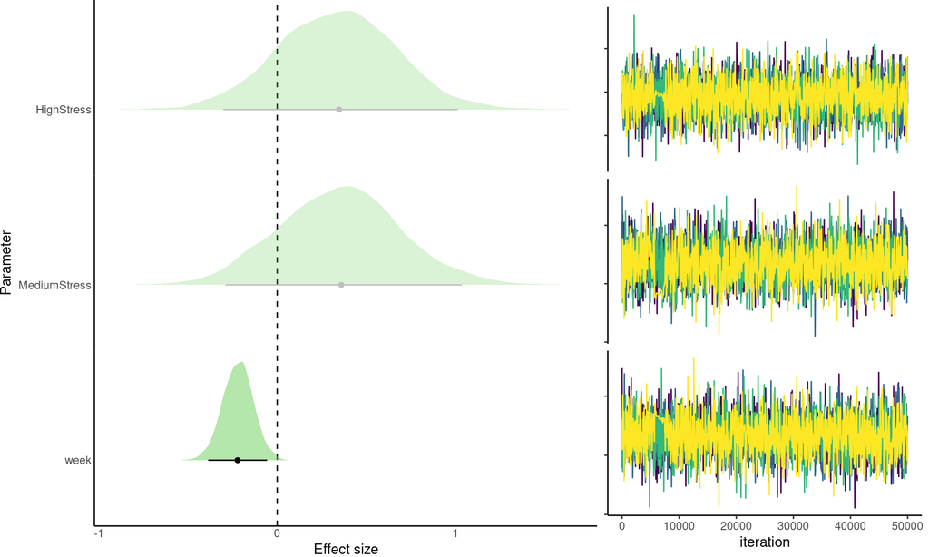

## behav-acoustic.diversity by treatment + week + (1|ID) + (1|round)

|  | formula | family | priors | iterations | chains | thinning | warmup | diverg_transitions | rhats > 1.05 | min_bulk_ESS | min_tail_ESS | seed |
| --- | --- | --- | --- | --- | --- | --- | --- | --- | --- | --- | --- | --- |
| 1 | acoustic.diversity ~ treatment + week + (1 \| ID) + (1 \| round) | gaussian (identity) | b-normal(0, 5) Intercept-normal(0, 10) sd-student_t(3, 0, 10) sigma-student_t(3, 0, 10) | 50000 | 4 | 1 | 25000 | 5858 (0.059%) | 0 | 134.805 | 46.971 | 1944177057 |

|  | Estimate | l-95% CI | u-95% CI | Rhat | Bulk_ESS | Tail_ESS |
| --- | --- | --- | --- | --- | --- | --- |
| HighStress | -0.237 | -1.119 | 0.628 | 1.007 | 404.743 | 588.708 |
| MediumStress | -0.731 | -1.568 | 0.139 | 1.011 | 372.659 | 2101.106 |
| week | 0.030 | -0.122 | 0.150 | 1.019 | 134.805 | 46.971 |

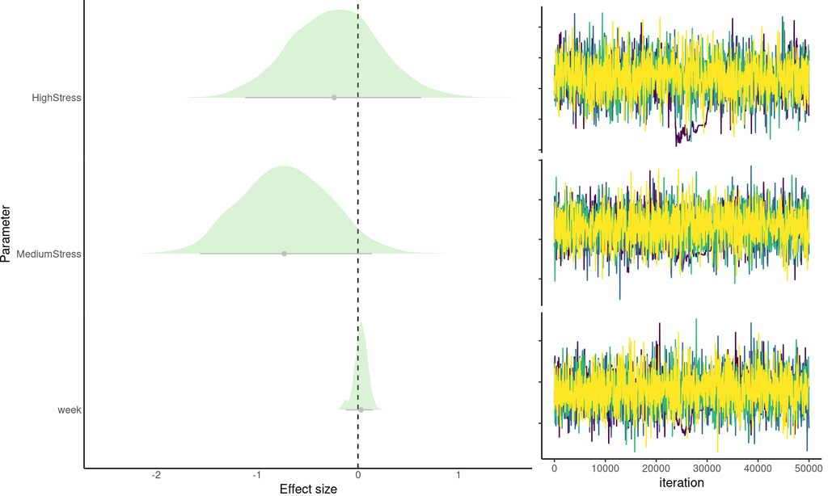

## behav-acustic.plasticity by treatment + week + (1|ID) + (1|round)

|  | formula | family | priors | iterations | chains | thinning | warmup | diverg_transitions | rhats > 1.05 | min_bulk_ESS | min_tail_ESS | seed |
| --- | --- | --- | --- | --- | --- | --- | --- | --- | --- | --- | --- | --- |
| 1 | acustic.plasticity ~ treatment + week + (1 \| ID) + (1 \| round) | gaussian (identity) | b-normal(0, 5) Intercept-normal(0, 10) sd-student_t(3, 0, 10) sigma-student_t(3, 0, 10) | 50000 | 4 | 1 | 25000 | 12819 (0.13%) | 1 | 42.584 | 116.274 | 797731249 |

|  | Estimate | l-95% CI | u-95% CI | Rhat | Bulk_ESS | Tail_ESS |
| --- | --- | --- | --- | --- | --- | --- |
| HighStress | -0.876 | -1.719 | -0.076 | 1.012 | 309.197 | 21107.209 |
| MediumStress | -0.166 | -1.116 | 0.709 | 1.056 | 42.584 | 116.274 |
| week | 0.168 | 0.035 | 0.304 | 1.015 | 2154.225 | 11799.347 |

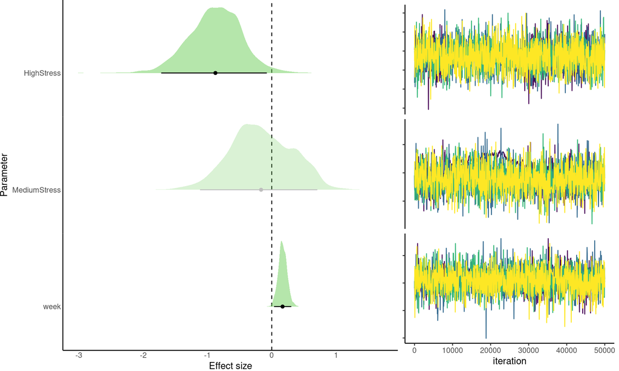

## behav-call.count by treatment + week + (1|ID) + (1|round)

|  | formula | family | priors | iterations | chains | thinning | warmup | diverg_transitions | rhats > 1.05 | min_bulk_ESS | min_tail_ESS | seed |
| --- | --- | --- | --- | --- | --- | --- | --- | --- | --- | --- | --- | --- |
| 1 | call.count ~ treatment + week + (1 \| ID) + (1 \| round) | gaussian (identity) | b-normal(0, 5) Intercept-normal(0, 10) sd-student_t(3, 0, 10) sigma-student_t(3, 0, 10) | 50000 | 4 | 1 | 25000 | 4442 (0.044%) | 0 | 1125.379 | 168.92 | 2114148139 |

|  | Estimate | l-95% CI | u-95% CI | Rhat | Bulk_ESS | Tail_ESS |
| --- | --- | --- | --- | --- | --- | --- |
| HighStress | 0.771 | 0.205 | 1.350 | 1.006 | 1125.379 | 168.920 |
| MediumStress | 0.385 | -0.176 | 0.966 | 1.006 | 1668.915 | 1165.582 |
| week | -0.057 | -0.203 | 0.085 | 1.003 | 1403.365 | 8883.471 |

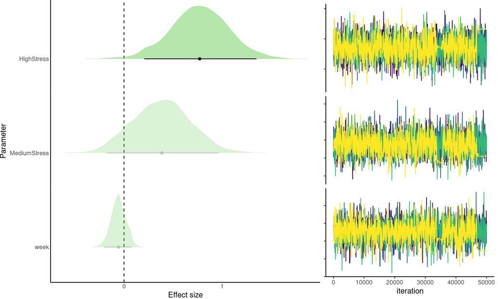

## Takeaways

- Higher vocal output in “high stress” birds compared to control
- Lower acoustic plasticity to themselves in week 1 for “high stress” birds compared to control
- Increase inacoustic plasticity over time

# FOXP2

## FoxP2 positive cells in MMST:VSP

```r
data_table(foxp2)
```

|  | Bird.ID | Treatment | FoxP2.Counts.MMSt.Striatum |
| --- | --- | --- | --- |
| 1 | 310YGHM | Control | 0.761613 |
| 2 | 390WBHM | High stress | 0.955224 |
| 3 | 371YYLM | High stress | 0.808994 |
| 4 | 388YGLM | Medium stress | 1.353515 |
| 5 | 398WGHM | Control | 0.759543 |
| 6 | 377WWLM | Control | 1.197626 |
| 7 | 404WBHM | High stress | 1.036214 |
| 8 | 300YGHM | High stress | 0.731717 |
| 9 | 258YGHM | High stress | 0.939208 |
| 10 | 125YGMM | Medium stress | 0.746397 |

[output cut: 8 more lines]

### Stats

```r
foxp2_mod <- brm(formula = FoxP2.Counts.MMSt.Striatum ~ Treatment,
    iter = 50000, family = Gamma(link = "log"), silent = 2, data = foxp2,
    control = list(adapt_delta = 0.9, max_treedepth = 15), chains = 4,
    cores = 4, file = "./data/processed/updated_regressions/foxp2_by_treatment_model",
    file_refit = "on_change", prior = c(prior(normal(0, 5), "b"),
        prior(normal(0, 10), "Intercept")))
```

```r
extended_summary(read.file = "./data/processed/updated_regressions/foxp2_by_treatment_model.rds",
    gsub.pattern = "b_treatment|b_", gsub.replacement = "", highlight = TRUE,
    remove.intercepts = TRUE)
```

## foxp2_by_treatment_model

|  | formula | family | priors | iterations | chains | thinning | warmup | diverg_transitions | rhats > 1.05 | min_bulk_ESS | min_tail_ESS | seed |
| --- | --- | --- | --- | --- | --- | --- | --- | --- | --- | --- | --- | --- |
| 1 | FoxP2.Counts.MMSt.Striatum ~ Treatment | gamma (log) | b-normal(0, 5) Intercept-normal(0, 10) shape-gamma(0.01, 0.01) | 50000 | 4 | 1 | 25000 | 0 (0%) | 0 | 64012.95 | 57759.07 | 1569240472 |

|  | Estimate | l-95% CI | u-95% CI | Rhat | Bulk_ESS | Tail_ESS |
| --- | --- | --- | --- | --- | --- | --- |
| TreatmentMediumstress | -0.015 | -0.285 | 0.257 | 1 | 64012.95 | 57759.07 |
| TreatmentHighstress | 0.070 | -0.202 | 0.340 | 1 | 64055.86 | 63249.42 |

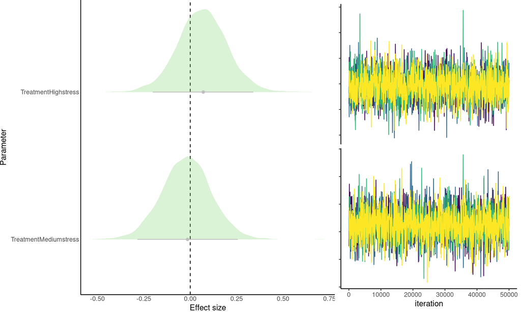

## FoxP2 mRNA expression MMST:VSP

```r
qpcr <- read.csv("./data/raw/INBREmale_qPCR_10Jun25.csv")
```

### Stats

```r
qpcr <- brm(formula = FoxP2.mRNA.MMST.VSP ~ Treatment, iter = 50000,
    family = Gamma(link = "log"), silent = 2, data = qpcr, control = list(adapt_delta = 0.9,
        max_treedepth = 15), chains = 4, cores = 4, file = "./data/processed/updated_regressions/qpcr_by_treatment_model",
    file_refit = "on_change", prior = c(prior(normal(0, 5), "b"),
        prior(normal(0, 10), "Intercept")))
```

```r
extended_summary(read.file = "./data/processed/updated_regressions/qpcr_by_treatment_model.rds",
    gsub.pattern = "b_treatment|b_", gsub.replacement = "", highlight = TRUE,
    remove.intercepts = TRUE)
```

## qpcr_by_treatment_model

|  | formula | family | priors | iterations | chains | thinning | warmup | diverg_transitions | rhats > 1.05 | min_bulk_ESS | min_tail_ESS | seed |
| --- | --- | --- | --- | --- | --- | --- | --- | --- | --- | --- | --- | --- |
| 1 | FoxP2.mRNA.MMST.VSP ~ Treatment | gamma (log) | b-normal(0, 5) Intercept-normal(0, 10) shape-gamma(0.01, 0.01) | 50000 | 4 | 1 | 25000 | 0 (0%) | 0 | 50123.37 | 39466.83 | 1212615228 |

|  | Estimate | l-95% CI | u-95% CI | Rhat | Bulk_ESS | Tail_ESS |
| --- | --- | --- | --- | --- | --- | --- |
| TreatmentHighStress | 0.438 | -0.281 | 1.142 | 1 | 50123.37 | 39466.83 |

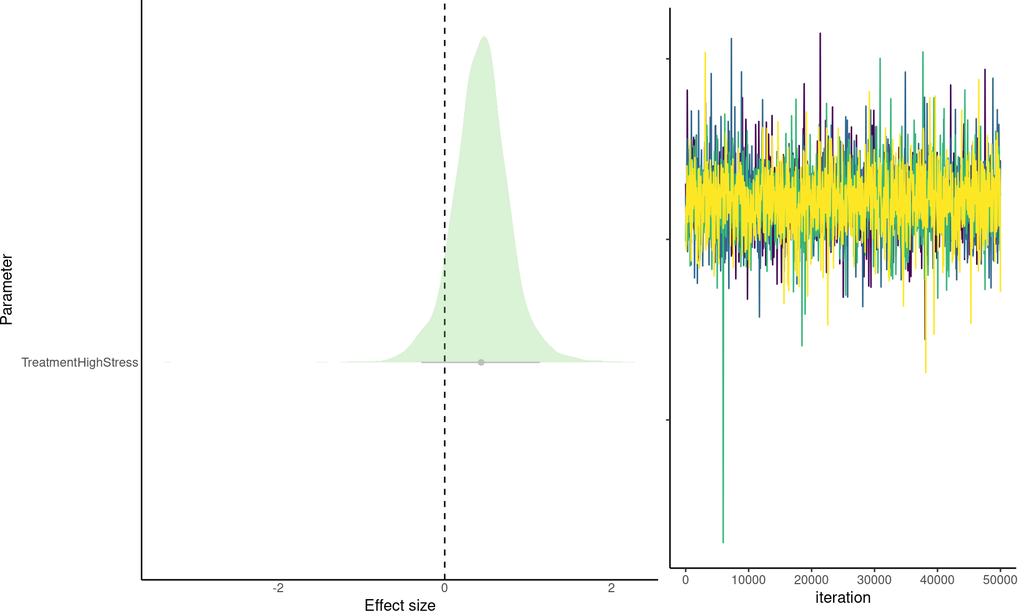

Barplot and effect sizes graph

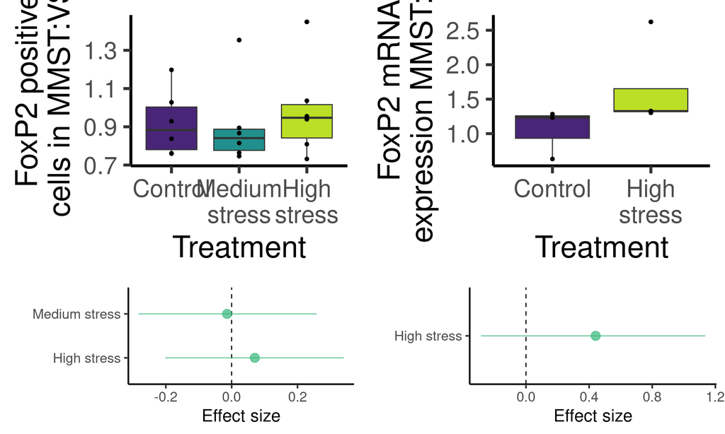

```r
gg_foxp2 <- ggplot(data = foxp2, aes(x = Treatment, y = FoxP2.Counts.MMSt.Striatum,
    fill = Treatment)) + geom_boxplot() + geom_point() + scale_x_discrete(labels = c(Control = "Control",
    `Medium stress` = "Medium\nstress", `High stress` = "High\nstress")) +
    scale_fill_viridis_d(begin = 0.1, end = 0.9) + labs(y = "FoxP2 positive\ncells in MMST:VSP",
    x = "Treatment") + theme_classic(base_size = 30) + theme(legend.position = "none")

gg_qpcr <- ggplot(data = qpcr, aes(x = Treatment, y = FoxP2.mRNA.MMST.VSP,
    fill = Treatment)) + geom_boxplot() + geom_point() + scale_x_discrete(labels = c(Control = "Control",
    `High Stress` = "High\nstress")) + scale_fill_viridis_d(begin = 0.1,
    end = 0.9) + labs(y = "FoxP2 mRNA\nexpression MMST:VSP", x = "Treatment") +
    theme_classic(base_size = 30) + theme(legend.position = "none")


foxp2_cells_mod <- readRDS("./data/processed/updated_regressions/foxp2_by_treatment_model.rds")
qpcr_mod <- readRDS("./data/processed/updated_regressions/qpcr_by_treatment_model.rds")

gg_coeffs_foxp2 <- lapply(list(foxp2_cells_mod, qpcr_mod), function(x) {

    vars <- grep("b_", posterior::variables(x), value = TRUE)
    draws <- posterior::as_draws_array(x, variable = vars)

    coef_table <- draw_summary(draws, variables = vars, probs = c(0.025,
        0.975), robust = TRUE, spread.type = "HPDI")

    coef_table$predictor <- rownames(coef_table)
    coef_table$predictor <- gsub("b_treatment|b_", "", coef_table$predictor)
    coef_table$predictor <- gsub("Stress", " stress", coef_table$predictor)
    coef_table$predictor <- gsub("week", "Week", coef_table$predictor)
    coef_table$predictor <- gsub("Treatment", "", coef_table$predictor)
    coef_table$predictor <- gsub("Mediumstress", "Medium stress",
        coef_table$predictor)
    coef_table$predictor <- gsub("Highstress", "High stress", coef_table$predictor)
    coef_table <- coef_table[coef_table$predictor != "Intercept",
        ]

    gg_coef <- ggplot2::ggplot(data = coef_table, aes(x = Estimate,
        y = predictor)) + geom_vline(xintercept = 0, lty = 2) + ggplot2::geom_point(size = 4,
        col = col_pointrange) + ggplot2::geom_errorbar(ggplot2::aes(xmin = `l-95% CI`,
        xmax = `u-95% CI`), width = 0, col = col_pointrange) + ggplot2::theme_classic(base_size = bs) +
        ggplot2::theme(axis.ticks.length = ggplot2::unit(0, "pt"),
            plot.margin = ggplot2::margin(0, 0, 0, 0, "pt"), legend.position = "none",
            strip.background = ggplot2::element_blank(), strip.text = ggplot2::element_blank()) +
        ggplot2::labs(x = "Effect size", y = "")

    return(gg_coef)
})

cowplot::plot_grid(gg_foxp2, gg_qpcr, gg_coeffs_foxp2[[1]] + theme_classic(base_size = bs),
    gg_coeffs_foxp2[[2]] + theme_classic(base_size = bs), nrow = 2,
    rel_heights = c(1.8, 1))
```

```r
# try bs = 20 for saving plots

# cowplot::ggsave2(filename =
# './output/bar_graphs_and_estimates_foxp2_70dpi.jpeg', width =
# 15, height = 10) cowplot::ggsave2(filename =
# './output/bar_graphs_and_estimates_foxp2_300dpi.jpeg', dpi =
# 300, width = 15, height = 10)
```

# Combined model diagnostics

```r
check_rds_fits(path = "./data/processed/updated_regressions", html = TRUE)
```

|  | fit | formula | family | priors | iterations | chains | thinning | warmup | diverg_transitions | rhats > 1.05 | min_bulk_ESS | min_tail_ESS | seed |
| --- | --- | --- | --- | --- | --- | --- | --- | --- | --- | --- | --- | --- | --- |
| 1 | behav-acoustic.convergence by treatment + week + (1\|ID) + (1\|round).rds | acoustic.convergence ~ treatment + week + (1 \| ID) + (1 \| round) | gaussian (identity) | b-normal(0, 5) Intercept-normal(0, 10) sd-student_t(3, 0, 10) sigma-student_t(3, 0, 10) | 50000 | 4 | 1 | 25000 | 2450 (0.0245%) | 0 | 1354.208 | 400.436 | 1891830873 |
| 2 | behav-acoustic.diversity by treatment + week + (1\|ID) + (1\|round).rds | acoustic.diversity ~ treatment + week + (1 \| ID) + (1 \| round) | gaussian (identity) | b-normal(0, 5) Intercept-normal(0, 10) sd-student_t(3, 0, 10) sigma-student_t(3, 0, 10) | 50000 | 4 | 1 | 25000 | 5858 (0.05858%) | 0 | 68.767 | 17.910 | 1944177057 |
| 3 | behav-acustic.plasticity by treatment + week + (1\|ID) + (1\|round).rds | acustic.plasticity ~ treatment + week + (1 \| ID) + (1 \| round) | gaussian (identity) | b-normal(0, 5) Intercept-normal(0, 10) sd-student_t(3, 0, 10) sigma-student_t(3, 0, 10) | 50000 | 4 | 1 | 25000 | 12819 (0.12819%) | 9 | 21.172 | 11.312 | 797731249 |
| 4 | behav-call.count by treatment + week + (1\|ID) + (1\|round).rds | call.count ~ treatment + week + (1 \| ID) + (1 \| round) | gaussian (identity) | b-normal(0, 5) Intercept-normal(0, 10) sd-student_t(3, 0, 10) sigma-student_t(3, 0, 10) | 50000 | 4 | 1 | 25000 | 4442 (0.04442%) | 0 | 324.539 | 89.262 | 2114148139 |
| 5 | foxp2_by_treatment_model.rds | FoxP2.Counts.MMSt.Striatum ~ Treatment | gamma (log) | b-normal(0, 5) Intercept-normal(0, 10) shape-gamma(0.01, 0.01) | 50000 | 4 | 1 | 25000 | 0 (0%) | 0 | 36874.784 | 47006.545 | 1569240472 |
| 6 | physio-baseline.CORT by treatment + week + (1\|ID) + (1\|round).rds | baseline.CORT ~ treatment + week + (1 \| ID) + (1 \| round) | gaussian (identity) | b-normal(0, 5) Intercept-normal(0, 10) sd-student_t(3, 0, 10) sigma-student_t(3, 0, 10) | 50000 | 4 | 1 | 25000 | 2088 (0.02088%) | 0 | 2542.551 | 914.854 | 824178344 |
| 7 | physio-breath.rate by treatment + week + (1\|ID) + (1\|round).rds | breath.rate ~ treatment + week + (1 \| ID) + (1 \| round) | gaussian (identity) | b-normal(0, 5) Intercept-normal(0, 10) sd-student_t(3, 0, 10) sigma-student_t(3, 0, 10) | 50000 | 4 | 1 | 25000 | 3008 (0.03008%) | 0 | 1730.003 | 706.441 | 289722089 |
| 8 | physio-stress.CORT by treatment + week + (1\|ID) + (1\|round).rds | stress.CORT ~ treatment + week + (1 \| ID) + (1 \| round) | gaussian (identity) | b-normal(0, 5) Intercept-normal(0, 10) sd-student_t(3, 0, 10) sigma-student_t(3, 0, 10) | 50000 | 4 | 1 | 25000 | 3672 (0.03672%) | 0 | 645.164 | 191.349 | 14709470 |
| 9 | physio-stress.response by treatment + week + (1\|ID) + (1\|round).rds | stress.response ~ treatment + week + (1 \| ID) + (1 \| round) | gaussian (identity) | b-normal(0, 5) Intercept-normal(0, 10) sd-student_t(3, 0, 10) sigma-student_t(3, 0, 10) | 50000 | 4 | 1 | 25000 | 3566 (0.03566%) | 0 | 1464.305 | 495.670 | 1084725584 |
| 10 | physio-weight by treatment + week + (1\|ID) + (1\|round).rds | weight ~ treatment + week + (1 \| ID) + (1 \| round) | gaussian (identity) | b-normal(0, 5) Intercept-normal(0, 10) sd-student_t(3, 0, 10) sigma-student_t(3, 0, 10) | 50000 | 4 | 1 | 25000 | 2418 (0.02418%) | 0 | 2251.696 | 1164.222 | 1985484202 |
| 11 | qpcr_by_treatment_model.rds | FoxP2.mRNA.MMST.VSP ~ Treatment | gamma (log) | b-normal(0, 5) Intercept-normal(0, 10) shape-gamma(0.01, 0.01) | 50000 | 4 | 1 | 25000 | 0 (0%) | 0 | 27641.137 | 30304.674 | 1212615228 |